# Part 3: Manuscript figures

Matt Fuller

2026-09-09

```r
library(elevatr)
library(terra)
library(sf)
library(spData)  # for US states polygons data(us_states, package = "spData")
library(mapdata)
library(usmap)
library(basemaps)
library(ggspatial)
library(ggtext)
library(ggridges)
library(GGally)
library(cowplot)
library(viridisLite)

# Linked micromaps dependencies
library(micromap)
library(RColorBrewer)
library(rmapshaper)
library(grid)
library(gridExtra)
library(gridGraphics)
library(ggplotify)
library(grDevices)

# last to supersede any other data wrangling fnxs in previously loaded packages
library(tidyverse)

threshold_temp_max <- 30
```

# 1 Read in data

```r
# read in prediction data
# Recent Climate scenarios
augm_rcnt <-          readRDS("../predictions/augm_rcnt.RDS")
augm_rcntdam <-       readRDS("../predictions/augm_rcntdam.RDS")
augm_rcntshade <-     readRDS("../predictions/augm_rcntshade.RDS")
augm_rcntdamshade <-  readRDS("../predictions/augm_rcntdamshade.RDS")

# Future Climate scenarios
augm_futr <-          readRDS("../predictions/augm_futr.RDS")
augm_futrdam <-      readRDS("../predictions/augm_futrdam.RDS")
augm_futrshade <-     readRDS("../predictions/augm_futrshade.RDS")
augm_futrdamshade <-  readRDS("../predictions/augm_futrdamshade.RDS")
```

```r
# observation and prediction site geospatial data
obs_df <- readRDS("../data/obs_df_MA_SSN.RDS")
preds_df <- readRDS("../data/preds_df_MA_SSN.RDS")

# geospatial river network lines
ma_edges<- readRDS(file = "../data/ssn_obj_edges.RDS")
```

```r
# Elevation threshold data frame to join to predictions for elevation banding
elev_band_width_m <- 10
elev_threshold_df <-
  data.frame(elev_band_min = seq(0,750,elev_band_width_m)) |>
  mutate(elev_band_mid = elev_band_min + (elev_band_width_m/2),
         elev_band_max = elev_band_min + elev_band_width_m) |>
  group_by(elev_band = cut(elev_band_mid+1,
                           breaks= seq(0, 750, elev_band_width_m)) ) |>ungroup()

# Function to calculated proportion of sites/reach length for a scenario that
# is gained or lost when compared to the recent climate baseline. Dependent on
# two inputs: scenario predictions from augment() scenario character string name
# There are other required background inputs that are not changed that include:
# the elevation band df for the recent climate scenario as a baseline
# (elev_band_00rcnt) and the "elev_threshold_df" R df that holds the elevation
# band min/mid/max values and the factored bands column.
elev_band_proportion_fnx <- function(augment_df, scenario_name) {
  elev_band_df <- augment_df |>
    # remove sf geometry
    st_drop_geometry() |>
    # grab the total reach length and number of reaches for each elevation band
    # filter to cold reaches
    filter(.fitted <= 20) |>
    # count reaches and sum up the length of stream within each elevation band
    group_by(elev_band = cut(v2elevm, breaks= seq(0, 750, elev_band_width_m)) ) |>
    reframe(clim_cond = scenario_name,
            n_sites = n(),
            reach_km = sum(Shape_Leng)/1000) |>
    # join the elevation band threshold df to this summary
    right_join(elev_threshold_df, by = c("elev_band") ) |>
    # add the baseline prediction data to this scenario's summary data
    left_join(select(elev_band_00rcnt, elev_band_mid,
                     n_sites_rcnt = n_sites, reach_km_rcnt = reach_km,
                     n_sites_tot, reach_km_tot),
              by = c("elev_band_mid")) |>
    # calculate the relative stats based on the baseline scenario data
    mutate(siteprop_n = (n_sites/n_sites_rcnt)-1,
           siteprop_km = (reach_km/reach_km_rcnt)-1,
           siteprop_n_tot = (n_sites/n_sites_tot),
           siteprop_km_tot = (reach_km/reach_km_tot))
  return(elev_band_df)
}
```

# 2 Figure 1: Study system map

## 2.1 Map data preparation

```r
# Grab edges and join to temperature predictions from recent climate scenario
ma_streams_sf <-
  st_transform(left_join(x = ma_edges,
                         y = select(st_drop_geometry(augm_rcnt),
                                    rid, Tw_rcnt = .fitted,
                                    ssnid, AreaKm2, v2elevm, BFIc),
                         by = c("rid")) |>
                 left_join(y = select(st_drop_geometry(augm_rcntdam),
                                      rid, Tw_rcntdam = .fitted),
                           by = c("rid")) |>
                 left_join(y = select(st_drop_geometry(augm_rcntshade),
                                      rid, Tw_rcntshade = .fitted),
                           by = c("rid")) |>
                 left_join(y = select(st_drop_geometry(augm_rcntdamshade),
                                      rid, Tw_rcntdamshade = .fitted),
                           by = c("rid")) |>
                 left_join(y = select(st_drop_geometry(augm_futr),
                                      rid, Tw_futr = .fitted),
                           by = c("rid")) |>
                 left_join(y = select(st_drop_geometry(augm_futrdam),
                                      rid, Tw_futrdam = .fitted),
                           by = c("rid")) |>
                 left_join(y = select(st_drop_geometry(augm_futrshade),
                                      rid, Tw_futrshade = .fitted),
                           by = c("rid")) |>
                 left_join(y = select(st_drop_geometry(augm_futrdamshade),
                                      rid, Tw_futrdamshade = .fitted),
                           by = c("rid")),
               crs = 3857)

# create map extents using 7.5km buffer around streams of MA
map_bbox_buffer <- 7500
map_extent <-
  st_bbox(st_buffer(filter(ma_streams_sf, !is.na(Tw_rcnt) | TotDASqKM > 5000),
                    dist = map_bbox_buffer),
          crs = 3857)


# North America inset/secondary plot for reference of CONUS
usa <- map_data("usa")
us_states <- map_data("state")
ne_states <- us_states |>
  filter(region %in% c("connecticut", "maine", "massachusetts", "new hampshire",
                       "rhode island", "vermont"))
# This scale provides better MA state boundary resolution
ma_state_boundary <-
  rnaturalearth::ne_states(country = c("United States of America"),
                           returnclass = "sf") |>
  filter(name == "Massachusetts")

canada <- map_data("worldHires", "Canada")
mexico <- map_data("worldHires", "Mexico")
NA_map_ggplot <- ggplot() +
  geom_polygon(data = canada, aes(x = long, y = lat, group = group),
               fill = "white", color = "grey20", linewidth = 0.1) +
  geom_polygon(data = mexico, aes(x = long, y = lat, group = group),
               fill = "white", color = "grey20", linewidth = 0.1) +
  geom_polygon(data = us_states, aes(x = long, y = lat, group = group),
               fill = "grey70", color = "grey20", linewidth = 0.1) +
  geom_polygon(data = ne_states, aes(x = long, y = lat, group = group),
               fill = "red", color = "red", linewidth = 0.1) +
  geom_polygon(data = usa, aes(x = long, y = lat, group = group),
               fill = NA, color = "grey20", linewidth = 0.25) +
  coord_sf(crs = 3857) +
  theme_void()
# NA_map_ggplot
```

```r
# Get the boundary for Massachusetts
ma_boundary <- st_as_sf(maps::map("state", "massachusetts", plot = FALSE, fill = TRUE))

# Download the DEM for Massachusetts (using a zoom level for ~30m resolution)
# For a higher resolution closer to 10m, increase the zoom level (e.g., z = 14)
# Note: Higher zoom levels will significantly increase download and processing time.
ma_dem <- get_elev_raster(locations = ma_boundary, z = 9, clip = "locations")


# Define the breaks for the elevation bands
elevation_breaks <- c(0, 100, 200, 300, 400, 500, 600, Inf)
# Define corresponding labels for the bands
elevation_labels <-
  c("0-100", "100-200", "200-300", "300-400", "400-500", "500-600", ">600")
# One color per band using Cividis (option "C")
n_bands   <- length(elevation_labels)
band_cols <- viridisLite::viridis(n_bands, option = "C")  # or viridis::viridis


# Convert the DEM to a data frame for ggplot
ma_dem_df <- as.data.frame(ma_dem, xy = TRUE)
colnames(ma_dem_df) <- c("x", "y", "elevation")
ma_dem_df <- na.omit(ma_dem_df)


# Create a new column in the dataframe with the binned data
ma_dem_df$elevation_band <- cut(ma_dem_df$elevation,
                                breaks = elevation_breaks,
                                labels = elevation_labels,
                                right = FALSE, # Use [0, 100) intervals
                                include.lowest = TRUE)

# Factor for elevation bands
ma_dem_df$elev_band <- factor(ma_dem_df$elevation_band, levels = elevation_labels)
# Ordered, numeric index for elevation bands for plotting DEM raster by band
ma_dem_df$band_index = as.integer(ma_dem_df$elev_band)


# Generate major contour lines (100m intervals)
major_breaks <- seq(0, 800, 100)
major_contours <- raster::rasterToContour(ma_dem, levels = major_breaks)
major_contours_sf <- st_as_sf(major_contours)

# Generate minor contour lines (50m intervals)
minor_breaks <- seq(50, 750, 100)
minor_contours <- raster::rasterToContour(ma_dem, levels = minor_breaks)
minor_contours_sf <- st_as_sf(minor_contours)

# --- Create USA Inset Map ---
# Get USA map data
usa_map <- st_as_sf(maps::map("state", plot = FALSE, fill = TRUE))

# Define the Northeast region
ne_states <-
  c("massachusetts", "connecticut", "rhode island", "vermont", "new hampshire", "maine")
ne_map <- subset(usa_map, ID %in% ne_states)

# --- Create Northeast Inset Map ---
ne_inset <- ggplot() +
  geom_sf(data = ne_map, fill = "white", color = "black", linewidth = 0.1) +
  geom_sf(data = ma_boundary, fill = "red") +
  theme_void() +
  theme(panel.border = element_blank())
```

## 2.2 Fig 1A. Stream network map

```r
# Create the main map of Massachusetts with a Cividis discrete color palette
main_map_network <- ggplot() +
  # Add the state boundary
  geom_sf(data = ma_state_boundary, fill = NA, color = "grey20", linewidth = 0.5) +
  # add stream network with drainage area weighted linewidth
  geom_sf(data = filter(ma_streams_sf, TotDASqKM < 2550 & Tw_rcnt < 34),
          aes(linewidth = TotDASqKM) , color = "#A6CEE3", lineend = "round") +
  scale_linewidth(range = c(0.1, 1.25)) +

  # add Connecticut and Merrimack Rivers
  geom_sf(data = filter(ma_streams_sf, TotDASqKM > 5000),
          color = "#1F78B4", linewidth = 0.8, lineend = "round") +
  geom_text(aes(x = -72.6, y = 42.94, hjust = 1),
            label  = "Connecticut River", size = 3) +
  geom_text(aes(x = -71.4, y = 42.94, hjust = 0),
            label  = "Merrimack River", size = 3) +

  # add the observation sites
  geom_sf(data = obs_df, fill = "#FF7F00", shape = 21,
          color = "#B34700",
          stroke = 0.2, size = 2) +

  # Add North Arrow
  annotation_north_arrow(
    location = "tr",       # Top right location
    which_north = "true",
    pad_x = unit(0.2, "in"), # Padding from the edge
    pad_y = unit(0.2, "in"),
    style = north_arrow_fancy_orienteering # A decorative style
  ) +

  # Add Scale Bar
  annotation_scale(
    location = "tr",       # Bottom left location
    bar_cols = c("black", "white"),
    width_hint = 0.18,      # Relative width of the scale bar (30% of map width)
    pad_y = unit(3, "cm")
  ) +

  # Set map coordinates
  coord_sf(crs = st_crs(ma_boundary)) +

  theme_void() +
  theme(axis.title = element_blank(),
        plot.background = element_rect(fill = "white"),
        legend.position = "none")

# Final map with insets
network_map <- ggdraw(main_map_network) +
    draw_plot(NA_map_ggplot, x = 0.02, y = 0.02, width = 0.3, height = 0.4) +
    draw_plot(ne_inset, x = 0.25, y = 0.05, width = 0.35, height = 0.4)
```

```r
# ggsave(plot = network_map, width = 6.5, height = 4.5, units = "in",
#        dpi = 600, filename = "../figures/fig1_optionB_studymap.png")
#
# ggsave(plot = network_map, width = 6.5, height = 4.5, units = "in",
#        device = cairo_ps,
#        dpi = 600, filename = "../figures/fig1_studymap.eps")
```

## 2.3 Fig 1B. Topographic DEM Map

```r
# Create the main map of Massachusetts with a Cividis discrete color palette
elevation_map <- ggplot() +
  # Add the DEM raster layer using the discrete 'elevation_band'
  geom_raster(data = ma_dem_df,
              aes(x = x, y = y, fill = band_index)) +

  # add Connecticut and Merrimack Rivers
  geom_sf(data = filter(ma_streams_sf, TotDASqKM > 5000),
          color = "black", linewidth = 0.8, lineend = "round") +
  geom_text(aes(x = -72.6, y = 42.94, hjust = 1),
            label  = "Connecticut River", size = 3) +
  geom_text(aes(x = -71.4, y = 42.94, hjust = 0),
            label  = "Merrimack River", size = 3) +

  # Stepped colour bar guide: looks like a horizontal gradient strip
  scale_fill_stepsn(
    colors = band_cols,
    breaks  = seq_len(n_bands),
    labels  = gsub("-", "\u2013", elevation_labels),  # add en dash to bands
    limits = c(1,8.5),
    na.value = "transparent",  # "transparent" to avoid showing NA pixels
    guide = guide_colorsteps(
      direction = "horizontal",
      title.position = "top",
      label.position = "bottom",
      ticks = TRUE,
      even.steps = TRUE,
      barwidth  = unit(6, "cm"),
      barheight = unit(4, "mm")
    )
  ) +

  # Add North Arrow
  annotation_north_arrow(
    location = "tr",       # Top right location
    which_north = "true",
    pad_x = unit(0.2, "in"), # Padding from the edge
    pad_y = unit(0.2, "in"),
    style = north_arrow_fancy_orienteering # A decorative style
  ) +

  # Add Scale Bar
  annotation_scale(
    location = "tr",       # Bottom left location
    bar_cols = c("black", "white"),
    # text_family = "Arial",
    width_hint = 0.18,      # Relative width of the scale bar (30% of map width)
    pad_y = unit(2.4, "cm")
  ) +

  # Set map coordinates
  coord_sf(crs = st_crs(ma_boundary)) +

  # Add titles and labels
  labs(fill = "Elevation Band (m)") +  # Update the legend title
  theme_void() +
  theme(plot.background = element_rect(fill = "white"),
        legend.position = "inside",
        legend.position.inside = c(0.3, 0.25),
        legend.direction = "horizontal",
        legend.title = element_text(margin = margin(b = 4)),
        legend.text  = element_text(size = 8, angle = 45, hjust = 0.75)
  )
```

## 2.4 Figure 1. Panel Plot

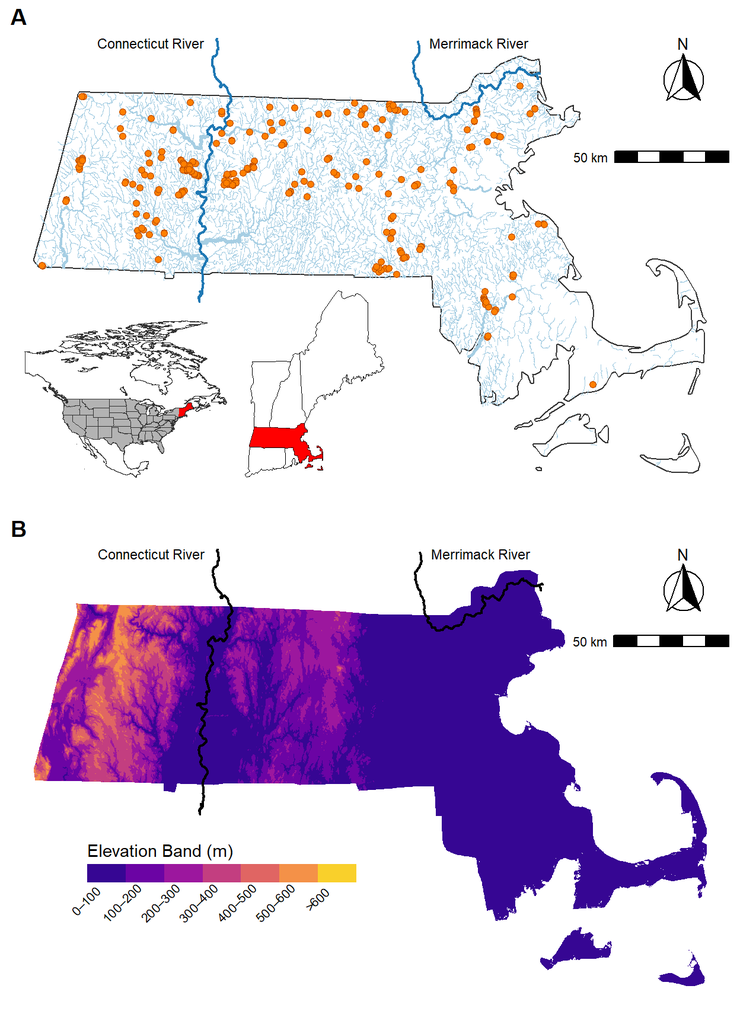

```r
(fig1_panel <-
  cowplot::plot_grid(network_map, elevation_map,
                     labels = c("A ","B "),
                     nrow = 2) +
  theme(plot.background = element_rect(fill = "white",color = NA))
 )
```

```r
# ggsave(plot = fig1_panel, width = 6.5, height = 9, units = "in",
#        dpi = 600, filename = "../figures/Figure1_studyarea_and_dem.png")
#
# ggsave(plot = fig1_panel, width = 6.5, height = 9, units = "in",
#        device = cairo_ps,
#        dpi = 600, filename = "../figures/Figure1_studyarea_and_dem.eps")
```

# 3 Figures 2 & 4: Linked Micromaps

## 3.1 Micromap function modifications for FWS style formatting

### 3.1.1 Reset micromap functions as necessary

Use to revert to the original micromap function code as necessary.

```r
detach("package:micromap", unload = TRUE, character.only = TRUE)
library(micromap)
```

### 3.1.2 `axis_opts()` update

We need to modify the axis options function to get only x and y axes (no plot border) and provide x-axis tick marks with no x-axis labels. We modify the `axis_opt()` function in micromap to do this.

```r
axis_opts <- function(i, pl, a, limsx=NA, limsy=NA, border=TRUE, expx=FALSE){
  # i=p; a=att; limsx=tmp.limsx; limsy=c(tmp.limsy,tmp.median.limsy); border=FALSE; expx=FALSE

  # many features are "hidden" by simply coloring the same color as the background so
  #   if panel background is NA we assume "white" will effectively do the hiding
  bgcolor <- ifelse(!is.na(a[[i]]$panel.bgcolor), a[[i]]$panel.bgcolor, 'white')

  # specify label size as maximum of all requested label sizes
  label.size <- as.numeric(max(all_atts(a, 'xaxis.labels.size')))*10


  # limsy will sometimes be in the form (c(lower bound, upper bound, lower bound for the median , upper bound for the median))
  #   if thats the case, we split it into the two seperate limits here
  median.limsy <- NULL
  if(length(limsy)==4) {median.limsy <- limsy[3:4]; limsy <- limsy[1:2]}


  ##############
  ### X axis ###
  ##############
  # with ggplot2, most axis specifications need to be made through the "scale_x_continuous()" function. there
  #   are 5 arguements: title, breaks (tick locations), labels (tick labels), limits (data limits), and expand (the
  #   extent to which the axis is expanded beyond the limits of the data). these specifications must be made
  #     all at once so we build this statement as a string and then execute it through an "eval" statement at the end

  # the following boolean variables state whether to include these specifications in the scale_x_continuous statement
  #     we start by assuming none except title will be needed
  x.breaks <- x.labels <- x.limits <- x.expand <- FALSE


  ### axis title ###
  xstr.title <- "''"

  # If all axis titles aren't NA then we must change the other titles to be blank in order to leave space
  #     for them at the bottom. If any title is multiple lines (ie contains '\n') then we must add in
  #     the correct number of character returns to the other titles in order to make the plot uniform
  if(!all(is.na(all_atts(a, 'xaxis.title')))){
    tmp.size <- max(as.numeric(all_atts(a, 'xaxis.title.size')))*8      # All titles must be same size. Default size is 8
    tmp.lineheight <- as.numeric(all_atts(a, 'xaxis.title.lineheight'))
    tmp.lineheight <- tmp.lineheight[which.max(abs(tmp.lineheight-1))]  # All line heights must be equal so we use the height
    # most drastically different from 1


    tmp.titles <- lapply(all_atts(a, 'xaxis.title'), function(t) if(is.na(t)|t=='') t=' ' else t)
    tmp.title <- tmp.titles[[i]]
    ns <- max(unlist(lapply(tmp.titles, function(x) length(strsplit(x, '\n')[[1]])))) - length(strsplit(tmp.title,'\n')[[1]])
    if(ns>0) tmp.title <- paste(tmp.title, rep(' \n ',ns), sep='')

    xstr.title <- paste("'",tmp.title,"'",sep='')
    pl <- pl + theme(axis.title.x = element_text(family=a[[i]]$xaxis.title.font, face=a[[i]]$xaxis.title.face,
                                                 colour=a[[i]]$xaxis.title.color, size=tmp.size, lineheight=tmp.lineheight))
  }


  ### axis limits and expansion ###
  if (!any(is.na(limsx))) x.limits <- TRUE

  # if there is a border to be added, we must manually deal with expansion
  if(!expx){
    x.expand <- TRUE
    xstr.expand <- as.character(", expand=c(0,0)")
  }

  xstr.limits <- as.character(paste('c(',min(limsx), ',', max(limsx),')'))
  xstr.limits <- paste(", limits=", xstr.limits)



  ### panel footers (not completed) ###
  # "panel footers" are really just augmented x axis titles
  # if all axis titles are blank then we hide axis titles on the whole plot
  if(all(is.na(all_atts(a, 'xaxis.title')))) pl <- pl + theme(axis.title.x = element_blank())


  ### axis lines ###
  # note: axis lines are always there, if the user doesn't want to
  #       see them they are colored to match the background
  if (!a[[i]]$xaxis.line.display & !a[[i]]$yaxis.line.display) {
    # ~~~~~~~~~~~~~~~~~~~~~~~~~~~~~~~~~~~~~~~~~~~~~~~~~~~~~~~~~~~~~~~~~~~~~~~~~~~
    # MRF edit: bgcolor was swapped out for 'black' to make the axis lines visible in the legend
    # ~~~~~~~~~~~~~~~~~~~~~~~~~~~~~~~~~~~~~~~~~~~~~~~~~~~~~~~~~~~~~~~~~~~~~~~~~~~
    pl <- pl + theme(axis.line = element_line(colour='black'))

    # else lines will be plotted
  } else {
    pl <- pl + theme(axis.line = element_line(colour='black'))
  }


  ### axis ticks ###
  # for now we assume ticks are never wanted as they make things pretty cluttered looking
  # ~~~~~~~~~~~~~~~~~~~~~~~~~~~~~~~~~~~~~~~~~~~~~~~~~~~~~~~~~~~~~~~~~~~~~~~~~~~~~
  # ~~~~~~~~~~~~~~~~~~~~~~~~~~~~~~~~~~~~~~~~~~~~~~~~~~~~~~~~~~~~~~~~~~~~~~~~~~~~~
  #   COMMENTED THE AXIS TICK BLANK CODE OUT SO THEY APPEAR
  # ~~~~~~~~~~~~~~~~~~~~~~~~~~~~~~~~~~~~~~~~~~~~~~~~~~~~~~~~~~~~~~~~~~~~~~~~~~~~~
  # ~~~~~~~~~~~~~~~~~~~~~~~~~~~~~~~~~~~~~~~~~~~~~~~~~~~~~~~~~~~~~~~~~~~~~~~~~~~~~
  # pl <- pl + theme(axis.ticks = element_blank())
  # ~~~~~~~~~~~~~~~~~~~~~~~~~~~~~~~~~~~~~~~~~~~~~~~~~~~~~~~~~~~~~~~~~~~~~~~~~~~~~
  # ~~~~~~~~~~~~~~~~~~~~~~~~~~~~~~~~~~~~~~~~~~~~~~~~~~~~~~~~~~~~~~~~~~~~~~~~~~~~~


  ### axis text ###
  # trys to hide axis text on the whole plot
  if(!any(all_attsb(a, 'xaxis.text.display'))) {
    pl <- pl + theme(axis.text.x = element_blank())

    # otherwise trys to "hide" axis text on this panel
  } else if (!a[[i]]$xaxis.text.display) {
    pl <- pl + theme(axis.text.x = element_text(colour=bgcolor, size=label.size))

    # axis text will show and we'll add specific labels if requested
  } else if (!is.na(unlist(a[[i]]$xaxis.labels)[1]) &
             !is.na(unlist(a[[i]]$xaxis.ticks)[1])) {

    tmpTheme <- "theme(axis.text.x = element_text(size=label.size"
    if(!is.null(a[[i]]$xaxis.labels.angle)) tmpTheme <- paste(tmpTheme, ", angle = ", a[[i]]$xaxis.labels.angle)
    if(!is.null(a[[i]]$xaxis.labels.hjust)) tmpTheme <- paste(tmpTheme, ", hjust =", a[[i]]$xaxis.labels.hjust)
    if(!is.null(a[[i]]$xaxis.labels.vjust)) tmpTheme <- paste(tmpTheme, ", vjust =", a[[i]]$xaxis.labels.vjust)
    tmpTheme <- paste(tmpTheme, "))")

    pl <- pl + eval(parse(text=tmpTheme ))

    x.breaks <- x.labels <- TRUE
    xstr.breaks <- paste(', breaks=c(', make.string(a[[i]]$xaxis.ticks),')',sep='')
    xstr.labels <- paste(', labels=c(', make.string(a[[i]]$xaxis.labels),')',sep='')

    # warning if user only specified text but not location or vice versa
  } else if (!is.na(unlist(a[[i]]$xaxis.labels)[1]) |
             !is.na(unlist(a[[i]]$xaxis.ticks)[1])) {
    print('Warning: both axis labels AND tick location must be specified')

    # otherwise text shows up as ggplot defaults
  }

  # transformation string
  xstr.trans <- paste0(', trans = ', a[[i]]$trans)

  xstr <- paste("scale_x_continuous(", xstr.title, xstr.trans)
  if (x.expand) xstr <- paste(xstr, xstr.expand)
  if (x.breaks) xstr <- paste(xstr, xstr.breaks)
  if (x.labels) xstr <- paste(xstr, xstr.labels)
  if (x.limits) xstr <- paste(xstr, xstr.limits)
  xstr <- paste(xstr, ")")

  pl <- pl + eval(parse(text=xstr))



  ##############
  ### Y axis ###
  ##############
  # with ggplot2, most axis specifications need to be made through the "scale_y_continuous()" function. there
  #   are 5 arguements: title, breaks (tick locations), labels (tick labels), limits (data limits), and expand (the
  #   extent to which the axis is expanded beyond the limits of the data). these specifications must be made
  #   all at once so we build this statement as a string and then execute it through an "eval" statement at the end

  ### axis title ###
  ystr.title  <- ifelse(!is.na(a[[i]]$yaxis.title), a[[i]]$yaxis.title, "''")


  ### axis text ###
  if(a[[i]]$yaxis.ticks.display | a[[i]]$yaxis.text.display) ystr.breaks <- "" else ystr.breaks <- ", breaks=NULL"


  ### axis limits and expansion ###
  ystr.expand <- ", expand=c(0,0)"
  limsy <- limsy + c(-1,1) * diff(limsy)*a$plot.pGrp.spacing

  ystr.limits <- as.character(paste('c(',min(limsy), ',', max(limsy),')'))
  ystr.limits <- paste(", limits=", ystr.limits)

  pl <- pl + theme(panel.spacing = unit(0, "lines"))


  # if (any(is.na(limsy)) | a$median.row) y.limits <- FALSE else y.limits <- TRUE


  # put it all together and execute the eval call
  ystr <- paste("scale_y_continuous(", ystr.title, ystr.expand, ystr.breaks)
  # if (y.limits) ystr <- paste(ystr, ystr.limits)
  ystr <- paste(ystr, ")")

  pl <- pl + eval(parse(text=ystr))


  ##############
  ### border ###
  ##############

  borderx <- range(limsx) + c(1,-1) * diff(range(limsx))*.001
  bordery <- range(limsy) + c(0, -1) * diff(range(limsy))*.001
  if(!is.null(median.limsy)) median.limsy <- range(median.limsy) - c(0, diff(range(median.limsy))*.001)

  tmp.border <- data.frame(pGrp=rep(1:max(pl$data$pGrp),each=2), ymin=bordery[1], ymax=bordery[2],
                           xmin=borderx[1], xmax=borderx[2])
  if(a$median.row) tmp.border <- rbind(subset(tmp.border, !pGrp==a$m.pGrp), data.frame(pGrp=a$m.pGrp, ymin=median.limsy[1], ymax=median.limsy[2],
                                                                                       xmin=borderx[1], xmax=borderx[2]))

  if(border) border.color <- a[[i]]$graph.border.color else border.color <- NA
  pl <- pl + geom_rect(aes(xmin = xmin, xmax=xmax, ymin=ymin, ymax=ymax), data=tmp.border,
                       colour= border.color, fill=NA)

  # ~~~~~~~~~~~~~~~~~~~~~~~~~~~~~~~~~~~~~~~~~~~~~~~~~~~~~~~~~~~~~~~~~~~~~~~~~~~~
  # ~~~~~~~~~~~~~~~~~~~~~~~~~~~~~~~~~~~~~~~~~~~~~~~~~~~~~~~~~~~~~~~~~~~~~~~~~~~~
  #       HERE I COMMENT OUT THE LINE THAT MAKES THE AXIS LINES DISAPPER/BLANK
  # ~~~~~~~~~~~~~~~~~~~~~~~~~~~~~~~~~~~~~~~~~~~~~~~~~~~~~~~~~~~~~~~~~~~~~~~~~~~~
  # ~~~~~~~~~~~~~~~~~~~~~~~~~~~~~~~~~~~~~~~~~~~~~~~~~~~~~~~~~~~~~~~~~~~~~~~~~~~~
  # pl <- pl + theme(axis.line = element_blank())
  # ~~~~~~~~~~~~~~~~~~~~~~~~~~~~~~~~~~~~~~~~~~~~~~~~~~~~~~~~~~~~~~~~~~~~~~~~~~~~
  # ~~~~~~~~~~~~~~~~~~~~~~~~~~~~~~~~~~~~~~~~~~~~~~~~~~~~~~~~~~~~~~~~~~~~~~~~~~~~

  pl

}

assignInNamespace("axis_opts", axis_opts, ns = "micromap")
```

### 3.1.3 `labels_build()` update

Modify the labels panel type plotting to accommodate parsed text in the elevation band meta data column of the micromap.

```r
labels_build <- function(pl, p, DF, att){

  DF$tmp.labels <- DF[,unlist(att[[p]]$panel.data)]

  #** The defaults are set up so that the text will, in theory, cover the entire
  #** width of the panel, whiel maximizing text height as well
  #** With the way the defaults are set up. default text size needs to be doubled
  tmp.tsize <- att[[p]]$text.size*4
  DF$tmp.y <- -DF$pGrpOrd*att[[p]]$text.size
  tmp.limsy <- c((min(-DF$pGrpOrd)-.5)*att[[p]]$text.size,
                 (max(-DF$pGrpOrd)+.5)*att[[p]]$text.size)

  mln <- max(nchar(as.character(DF$tmp.labels)))
  if (att[[p]]$align=='right') {
    tmp.limsx <- c(-mln,0)
    DF$tmp.adj <- 1
  }
  if (att[[p]]$align=='left') {
    tmp.limsx <- c(0,mln)
    DF$tmp.adj <- 0
  }
  if (att[[p]]$align=='center') {
    tmp.limsx <- c(-mln/2,mln/2)
    DF$tmp.adj <- .5
  }


  #################################
  #################################
  #*** insert space for median row
  tmp.median.limsy <- NULL

  if(att$median.row) {
    if(!any(DF$median)) DF <- rbind(DF, transform(DF[1,], pGrpOrd=1, pGrp=att$m.pGrp, median=TRUE,
                                                  rank='', tmp.y=-att[[p]]$text.size,
                                                  tmp.labels=''))


    tmp.median.limsy <- att[[p]]$text.size*c(-1.5,-.5)
  }


  #################################
  #################################


  pl <-
    ggplot(DF) +
    geom_text(aes(x=0, y=tmp.y, label=tmp.labels,
                  hjust=tmp.adj, vjust=.4),
              # ~~~~~~~~~~~~~~~~~~~~~~~~~~~~~~~~~~~~~~~~~~~~~~~~~~~~~~~~~~~~~~
              # ~~~~~~~~~~~~~~~~~~~~~~~~~~~~~~~~~~~~~~~~~~~~~~~~~~~~~~~~~~~~~~
              #   HERE IS WHERE I ADDED `parse = TRUE` to allow an italic "n"
              # ~~~~~~~~~~~~~~~~~~~~~~~~~~~~~~~~~~~~~~~~~~~~~~~~~~~~~~~~~~~~~~
              # ~~~~~~~~~~~~~~~~~~~~~~~~~~~~~~~~~~~~~~~~~~~~~~~~~~~~~~~~~~~~~~
              parse = TRUE,
              # ~~~~~~~~~~~~~~~~~~~~~~~~~~~~~~~~~~~~~~~~~~~~~~~~~~~~~~~~~~~~~~
              # ~~~~~~~~~~~~~~~~~~~~~~~~~~~~~~~~~~~~~~~~~~~~~~~~~~~~~~~~~~~~~~
              #   END OF MODIFICAITON OF THIS FUNCTION
              # ~~~~~~~~~~~~~~~~~~~~~~~~~~~~~~~~~~~~~~~~~~~~~~~~~~~~~~~~~~~~~~
              # ~~~~~~~~~~~~~~~~~~~~~~~~~~~~~~~~~~~~~~~~~~~~~~~~~~~~~~~~~~~~~~
              family=att[[p]]$text.font, fontface=att[[p]]$text.face, size=tmp.tsize) +
    facet_grid(pGrp~., scales="free_y", space="free") +
    scale_colour_manual(values=att$colors)

  pl <- plot_opts(p, pl, att)
  pl <- graph_opts(p, pl, att)
  pl <- axis_opts(p, pl, att, limsx=tmp.limsx, limsy=c(tmp.limsy,tmp.median.limsy), border=FALSE) +

    # ~~~~~~~~~~~~~~~~~~~~~~~~~~~~~~~~~~~~~~~~~~~~~~~~~~~~~~~~~~~~~~~~~~~~~~~~~~
    # ~~~~~~~~~~~~~~~~~~~~~~~~~~~~~~~~~~~~~~~~~~~~~~~~~~~~~~~~~~~~~~~~~~~~~~~~~~
    # ADDED THIS SO THAT THE LABELS DON'T HAVE AXES AND TICKS
    # ~~~~~~~~~~~~~~~~~~~~~~~~~~~~~~~~~~~~~~~~~~~~~~~~~~~~~~~~~~~~~~~~~~~~~~~~~~
    # ~~~~~~~~~~~~~~~~~~~~~~~~~~~~~~~~~~~~~~~~~~~~~~~~~~~~~~~~~~~~~~~~~~~~~~~~~~
    theme(axis.line = element_blank(), axis.ticks = element_blank())
    # ~~~~~~~~~~~~~~~~~~~~~~~~~~~~~~~~~~~~~~~~~~~~~~~~~~~~~~~~~~~~~~~~~~~~~~~~~~
    # ~~~~~~~~~~~~~~~~~~~~~~~~~~~~~~~~~~~~~~~~~~~~~~~~~~~~~~~~~~~~~~~~~~~~~~~~~~


  pl

}

assignInNamespace("labels_build", labels_build, ns = "micromap")
```

### 3.1.4 `box_summary_build()` update

Modify the box summary panel building function to accommodate FWS formatting.

```r
box_summary_build <- function(pl, p, DF, att){
  if(length(att[[p]]$panel.data)==5) iCols <- c(1,2,2,3,4,4,5) else iCols <- 1:7
  tmp.data <- DF[,unlist(att[[p]]$panel.data)]
  tmp.data <- tmp.data[,iCols]
  names(tmp.data) <- paste('tmp.data',1:7,sep='')
  DF <- cbind(DF, tmp.data)

  DF$tmp.adj <- att[[p]]$graph.bar.size

  tmp.limsx <- range(DF[,unlist(att[[p]]$panel.data)], na.rm=T)
  if(any(!is.na(att[[p]]$xaxis.ticks))) tmp.limsx <- range(c(tmp.limsx, att[[p]]$xaxis.ticks))
  tmp.limsx <- tmp.limsx + c(-1,1) * diff(tmp.limsx)*.05
  tmp.limsy <- -(range(DF$pGrpOrd) + c(-1,1) * .5)


  ncolors <- length(att$colors)
  #################################
  #################################
  #*** insert space for median row
  tmp.median.limsy <- NULL


  if(att$median.row) {
    if(!any(DF$median)) DF <- rbind(DF, transform(DF[1,], pGrpOrd=ncolors+1, pGrp=att$m.pGrp, median=TRUE, rank='',
                                                  tmp.data1=median(DF$tmp.data1),
                                                  tmp.data2=median(DF$tmp.data2),
                                                  tmp.data3=median(DF$tmp.data3),
                                                  tmp.data4=median(DF$tmp.data4),
                                                  tmp.data5=median(DF$tmp.data5),
                                                  tmp.data6=median(DF$tmp.data6),
                                                  tmp.data7=median(DF$tmp.data7)))


    DF$color[DF$median] <- ncolors
    tmp.median.limsy <- c(-.5, -1.5)    # c(0, -2)
  }

  #################################
  #################################

  pl  <-
    ggplot(DF) +
    geom_errorbarh(aes(xmin=tmp.data1, xmax=tmp.data7, y=-pGrpOrd),
                   height=.9*att[[p]]$graph.bar.size) +
    geom_rect(aes(xmin=tmp.data2, ymin=-pGrpOrd-(tmp.adj/4),
                  xmax=tmp.data5, ymax=-pGrpOrd+(tmp.adj/4),
                  fill=factor(color), colour='black')) +
    geom_rect(aes(xmin=tmp.data3, ymin=-pGrpOrd-(tmp.adj/2),
                  xmax=tmp.data6, ymax=-pGrpOrd+(tmp.adj/2),
                  fill=factor(color), colour='black')) +
    geom_segment(aes(x=tmp.data4, y=-pGrpOrd-(tmp.adj/2),
                     xend=tmp.data4, yend=-pGrpOrd+(tmp.adj/2)), colour='black') +
    facet_grid(pGrp~., scales="free_y",
               #~~~~~~~~~~~~~~~~~~~~~~~~~~~~~~~~~~~~~~~~~~~~~~~~~~~~~~~~~~~
               #~~~~~~~~~~~~~~~~~~~~~~~~~~~~~~~~~~~~~~~~~~~~~~~~~~~~~~~~~~~
               #   ADDED THESE AXES FORMATS FOR FWS
               #~~~~~~~~~~~~~~~~~~~~~~~~~~~~~~~~~~~~~~~~~~~~~~~~~~~~~~~~~~~
               #~~~~~~~~~~~~~~~~~~~~~~~~~~~~~~~~~~~~~~~~~~~~~~~~~~~~~~~~~~~
               axes = "all_x",
               axis.labels = "margins",
               #~~~~~~~~~~~~~~~~~~~~~~~~~~~~~~~~~~~~~~~~~~~~~~~~~~~~~~~~~~~
               #~~~~~~~~~~~~~~~~~~~~~~~~~~~~~~~~~~~~~~~~~~~~~~~~~~~~~~~~~~~
               space="free") +
    scale_colour_manual(values='black', guide='none') +
    scale_fill_manual(values=att$colors, guide='none')


  if(att[[p]]$median.line) pl <- pl + geom_vline(aes(xintercept = median(tmp.data)), data=DF,
                                                 colour=att[[p]]$median.line.col,
                                                 linetype = att[[p]]$median.line.typ,
                                                 linewidth = att[[p]]$median.line.size)

  if(!any(is.na(att[[p]]$add.line))){
    if(length(att[[p]]$add.line.col)==1) att[[p]]$add.line.col <- rep(att[[p]]$add.line.col[1], length(att[[p]]$add.line))
    if(length(att[[p]]$add.line.typ)==1) att[[p]]$add.line.typ <- rep(att[[p]]$add.line.typ[1], length(att[[p]]$add.line))
    if(length(att[[p]]$add.line.size)==1) att[[p]]$add.line.size <- rep(att[[p]]$add.line.size[1], length(att[[p]]$add.line))

    for(j in 1:length(att[[p]]$add.line)) pl <- pl + geom_vline(xintercept = att[[p]]$add.line[j],
                                                                colour=att[[p]]$add.line.col[j],
                                                                linetype=att[[p]]$add.line.typ[j],
                                                                linewidth=att[[p]]$add.line.size[j])
  }


  pl <- plot_opts(p, pl, att)
  pl <- graph_opts(p, pl, att)
  pl <- axis_opts(p, pl, att, limsx=tmp.limsx, limsy=c(tmp.limsy,tmp.median.limsy), expx=FALSE)
  #~~~~~~~~~~~~~~~~~~~~~~~~~~~~~~~~~~~~~~~~~~~~~~~~~~~~~~~~~~~~~~~~~~~~~~~~~~~
  #~~~~~~~~~~~~~~~~~~~~~~~~~~~~~~~~~~~~~~~~~~~~~~~~~~~~~~~~~~~~~~~~~~~~~~~~~~~
  # added theme details here for x-axis and ticks
  #~~~~~~~~~~~~~~~~~~~~~~~~~~~~~~~~~~~~~~~~~~~~~~~~~~~~~~~~~~~~~~~~~~~~~~~~~~~
  #~~~~~~~~~~~~~~~~~~~~~~~~~~~~~~~~~~~~~~~~~~~~~~~~~~~~~~~~~~~~~~~~~~~~~~~~~~~
  pl <- pl + theme(axis.line.x = element_line(color = "black"),
                   axis.line.y = element_line(color = "black"),
                   axis.ticks.x = element_line(color = "black"),
                   axis.ticks.y = element_blank(),
                   axis.text.y = element_blank(),
                   axis.title.y = element_blank())
  #~~~~~~~~~~~~~~~~~~~~~~~~~~~~~~~~~~~~~~~~~~~~~~~~~~~~~~~~~~~~~~~~~~~~~~~~~~~
  #~~~~~~~~~~~~~~~~~~~~~~~~~~~~~~~~~~~~~~~~~~~~~~~~~~~~~~~~~~~~~~~~~~~~~~~~~~~

  pl
}

assignInNamespace("box_summary_build", box_summary_build, ns = "micromap")
```

### 3.1.5 `bar_cl_build()` update

Modify the bar plot panel building function to accommodate FWS formatting.

```r
bar_cl_build <- function(pl, p, DF, att){
  DF$tmp.data1 <- DF[,att[[p]]$panel.data[[1]]]
  DF$tmp.data2 <- DF[,att[[p]]$panel.data[[2]]]
  DF$tmp.data3 <- DF[,att[[p]]$panel.data[[3]]]

  DF$tmp.adj <- att[[p]]$graph.bar.size

  tmp.limsx <- range(c(0, DF[,unlist(att[[p]]$panel.data)], na.rm=T))
  if(any(!is.na(att[[p]]$xaxis.ticks))) tmp.limsx <- range(c(tmp.limsx, att[[p]]$xaxis.ticks))
  tmp.limsx <- tmp.limsx + c(-.001,.05) * diff(tmp.limsx)
  tmp.limsy <- -(range(DF$pGrpOrd) + c(-1,1) * .5)


  ncolors <- length(att$colors)
  #################################
  #################################
  #*** insert space for median row
  tmp.median.limsy <- NULL

  if(att$median.row) {
    if(!any(DF$median)) DF <- rbind(DF, transform(DF[1,], pGrpOrd=ncolors+1, pGrp=att$m.pGrp, median=TRUE, rank='',
                                                  tmp.data1=median(DF$tmp.data1),
                                                  tmp.data2=median(DF$tmp.data2),
                                                  tmp.data3=median(DF$tmp.data3)))


    DF$color[DF$median] <- ncolors
    tmp.median.limsy <- c(-.5, -1.5)
  }

  #################################
  #################################

  pl  <-
    ggplot(DF) +
    geom_rect(aes(xmin=0, ymin=-pGrpOrd-(tmp.adj/2),
                  xmax=tmp.data1, ymax=-pGrpOrd+(tmp.adj/2),
                  fill=factor(color), colour='black')) +
    geom_errorbarh(aes(xmin=tmp.data2, xmax=tmp.data3, y=-pGrpOrd),
                   height=.9*att[[p]]$graph.bar.size) +
    theme_classic() +
    facet_grid(pGrp~., scales="free_y",
               #~~~~~~~~~~~~~~~~~~~~~~~~~~~~~~~~~~~~~~~~~~~~~~~~~~~~~~~~~~~
               #~~~~~~~~~~~~~~~~~~~~~~~~~~~~~~~~~~~~~~~~~~~~~~~~~~~~~~~~~~~
               #   ADDED THESE AXES FORMATS FOR FWS
               #~~~~~~~~~~~~~~~~~~~~~~~~~~~~~~~~~~~~~~~~~~~~~~~~~~~~~~~~~~~
               #~~~~~~~~~~~~~~~~~~~~~~~~~~~~~~~~~~~~~~~~~~~~~~~~~~~~~~~~~~~
               axes = "all_x",
               axis.labels = "margins",
               #~~~~~~~~~~~~~~~~~~~~~~~~~~~~~~~~~~~~~~~~~~~~~~~~~~~~~~~~~~~
               #~~~~~~~~~~~~~~~~~~~~~~~~~~~~~~~~~~~~~~~~~~~~~~~~~~~~~~~~~~~
               space="free") +
    scale_colour_manual(values='black', guide='none') +
    scale_fill_manual(values=att$colors, guide='none')


  if(att[[p]]$median.line) pl <- pl + geom_vline(aes(xintercept = median(tmp.data)),
                                                 colour=att[[p]]$median.line.col,
                                                 linetype = att[[p]]$median.line.typ,
                                                 linewidth = att[[p]]$median.line.size)

  if(!any(is.na(att[[p]]$add.line))){
    if(length(att[[p]]$add.line.col)==1) att[[p]]$add.line.col <- rep(att[[p]]$add.line.col[1], length(att[[p]]$add.line))
    if(length(att[[p]]$add.line.typ)==1) att[[p]]$add.line.typ <- rep(att[[p]]$add.line.typ[1], length(att[[p]]$add.line))
    if(length(att[[p]]$add.line.size)==1) att[[p]]$add.line.size <- rep(att[[p]]$add.line.size[1], length(att[[p]]$add.line))

    for(j in 1:length(att[[p]]$add.line)) pl <- pl + geom_vline(xintercept = att[[p]]$add.line[j],
                                                                colour=att[[p]]$add.line.col[j],
                                                                linetype=att[[p]]$add.line.typ[j],
                                                                linewidth=att[[p]]$add.line.size[j])
  }


  pl <- plot_opts(p, pl, att)
  pl <- graph_opts(p, pl, att)
  pl <- axis_opts(p, pl, att, limsx=tmp.limsx, limsy=c(tmp.limsy, tmp.median.limsy), expx=FALSE)
  #~~~~~~~~~~~~~~~~~~~~~~~~~~~~~~~~~~~~~~~~~~~~~~~~~~~~~~~~~~~~~~~~~~~~~~~~~~~
  #~~~~~~~~~~~~~~~~~~~~~~~~~~~~~~~~~~~~~~~~~~~~~~~~~~~~~~~~~~~~~~~~~~~~~~~~~~~
  # added theme details here for x-axis and ticks
  #~~~~~~~~~~~~~~~~~~~~~~~~~~~~~~~~~~~~~~~~~~~~~~~~~~~~~~~~~~~~~~~~~~~~~~~~~~~
  #~~~~~~~~~~~~~~~~~~~~~~~~~~~~~~~~~~~~~~~~~~~~~~~~~~~~~~~~~~~~~~~~~~~~~~~~~~~
  pl <- pl + theme(axis.line.x = element_line(color = "black"),
                   axis.line.y = element_line(color = "black"),
                   axis.ticks.x = element_line(color = "black"),
                   axis.ticks.y = element_blank(),
                   axis.text.y = element_blank(),
                   axis.title.y = element_blank(),
                   axis.text.x = element_text(angle = 25, hjust = 1))
  #~~~~~~~~~~~~~~~~~~~~~~~~~~~~~~~~~~~~~~~~~~~~~~~~~~~~~~~~~~~~~~~~~~~~~~~~~~~
  #~~~~~~~~~~~~~~~~~~~~~~~~~~~~~~~~~~~~~~~~~~~~~~~~~~~~~~~~~~~~~~~~~~~~~~~~~~~

  pl
}

assignInNamespace("bar_cl_build", bar_cl_build, ns = "micromap")
```

### 3.1.6 `CatMaps2()` update from `CatMaps()`

Modify the `CatMaps()` function and rename as `CatMaps2()` to accommodate FWS formatting.

```r
CatMaps2 <- function(pl, p, mapDF, att) {
  bgcolor <- ifelse(!is.na(att[[p]]$panel.bgcolor), att[[p]]$panel.bgcolor, "white")

  # Keep only mapped features with a panel-group assignment
  mapDF_active <- subset(mapDF, !is.na(pGrp))

  # All features drawn in every facet as inactive background
  mapDF_all <- transform(mapDF, pGrp = NULL)

  pl <- ggplot(mapDF_active, aes(x = coordsx, y = coordsy, group = poly)) +
    # Inactive background: all features in every facet
    geom_polygon(
      data = mapDF_all,
      fill = "lightgrey",
      colour = "lightgrey"
    ) +
    # Active features for the current facet/group
    geom_polygon(
      data = subset(mapDF_active, hole == 0),
      fill = "black",
      colour = "black"
    ) +
    # Holes inside active polygons
    geom_polygon(
      data = subset(mapDF_active, hole == 1),
      fill = "white",
      colour = "black"
    ) +
    # Preserve hole outlines
    geom_polygon(
      data = subset(transform(mapDF_active, pGrp = NULL), hole == 1),
      fill = "transparent",
      colour = "black"
    ) +
    facet_grid(pGrp ~ ., scales = "free_y", space = "free") +
    coord_cartesian(default = TRUE)

  bdrCoordsy <- att[[p]]$bdrCoordsy
  bdrCoordsy <- bdrCoordsy + c(1, -1) * diff(bdrCoordsy) * att$plot.pGrp.spacing
  bdrCoordsy <- bdrCoordsy + c(0, -1) * diff(range(bdrCoordsy)) * 0.001

  bdrCoordsx <- att[[p]]$bdrCoordsx
  bdrCoords <- data.frame(
    coordsx = bdrCoordsx,
    coordsy = bdrCoordsy,
    pGrp = NA,
    poly = NA
  )

  pl <- pl + geom_point(
    fill = bgcolor,
    size = 0.001,
    colour = bgcolor,
    data = transform(bdrCoords, pGrp = NULL)
  )

  xstr.title <- "''"
  if (!all(is.na(all_atts(att, "xaxis.title")))) {
    tmp.titles <- lapply(all_atts(att, "xaxis.title"), function(t) {
      if (is.na(t) | t == "") " " else t
    })
    tmp.title <- tmp.titles[[p]]
    ns <- max(unlist(lapply(tmp.titles, function(x) length(strsplit(x, "\n")[[1]])))) -
      length(strsplit(tmp.title, "\n")[[1]])
    if (ns > 0) tmp.title <- paste(tmp.title, rep(" \n ", ns), sep = "")
    xstr.title <- paste("'", tmp.title, "'", sep = "")

    pl <- pl + theme(
      axis.title.x = element_text(size = 8 * att[[p]]$xaxis.title.size, colour = bgcolor)
    )
  } else {
    pl <- pl + theme(axis.title.x = element_blank())
  }

  if (any(c(all_attsb(att, "xaxis.ticks.display"), all_attsb(att, "xaxis.text.display")))) {
    pl <- pl +
      theme(axis.text.x = element_text(colour = bgcolor)) +
      theme(axis.ticks = element_line(colour = bgcolor))
  } else {
    pl <- pl +
      theme(axis.text.x = element_blank()) +
      theme(axis.ticks = element_blank())
  }

  ystr <- "scale_y_continuous('', breaks=NULL, expand=c(0,0))"
  pl <- pl + eval(parse(text = ystr))

  pl <- plot_opts(p, pl, att)
  pl <- graph_opts(p, pl, att)
  pl <- pl + theme(panel.spacing = unit(0, "lines"))

  pl
}
```

### 3.1.7 `mmgroupedplot2()` modification from `mmgroupedplot()`

Modify the `mmgroupedplot()` function and rename as `mmgroupedplot2()` to accommodate FWS formatting.

`mmgroupedplot2()` depends on `CatMaps2()` above.

```r
mmgroupedplot2 <- function(stat.data, map.data, panel.types, panel.data,
                           map.link = NULL,
                           nPanels = length(panel.types),
                           grp.by, cat,
                           colors = brewer.pal(10, "Spectral"),
                           map.color = "lightyellow",
                           map.all = FALSE,
                           print.file = "no",
                           print.res = NA,
                           panel.att = vector("list", nPanels),
                           plot.header = NA,
                           plot.header.size = NA,
                           plot.header.color = NA,
                           plot.footer = NA,
                           plot.footer.size = NA,
                           plot.footer.color = NA,
                           footer.grid.unit.y.adj = 0.0225,
                           footer.grid.viewport.height = 0.9775,
                           footer.grid.viewport.y = 0.505,
                           plot.width = 7,
                           plot.height = 7,
                           map.spacing = 1,
                           plot.grp.spacing = 1,
                           plot.panel.spacing = 1,
                           plot.panel.margins = c(0, 0, 1, 0)) {

  dStats <- stat.data
  dMap <- map.data

  ncol <- length(unique(stat.data[, cat]))
  colors <- colorRampPalette(colors)(ncol)

  tPlot.header <- plot.header
  iPlot.header.size <- plot.header.size
  tPlot.header.color <- plot.header.color
  tPlot.footer <- plot.footer
  iPlot.footer.size <- plot.footer.size
  tPlot.footer.color <- plot.footer.color

  pps <- plot.panel.spacing * 0.05

  plot.atts <- list(
    plot.grp.spacing = plot.grp.spacing * 0.05,
    plot.pGrp.spacing = plot.grp.spacing * 0.05,
    plot.panel.margins = plot.panel.margins,
    grp.by = grp.by,
    colors = colors,
    map.color = map.color,
    map.spacing = map.spacing * 0.025,
    plot.width = plot.width,
    plot.height = plot.height
  )

  a <- vector("list", nPanels)

  ns <- asNamespace("micromap")

  for (p in 1:nPanels) {
    att.name <- paste(panel.types[p], "_att", sep = "")
    if (exists(att.name, envir = ns, mode = "function")) {
      a[[p]] <- get(att.name, envir = ns)()
    } else {
      a[[p]] <- get("standard_att", envir = ns)()
    }
  }

  a <- append(a, plot.atts)

  for (j in 1:length(panel.types)) {
    a[[j]] <- append(a[[j]], list(panel.data = unlist(panel.data[[j]])))
  }

  for (j in 1:length(panel.att)) {
    k <- unlist(panel.att[[j]][1], use.names = FALSE)
    for (s in names(panel.att[[j]])[-1]) {
      w <- match(s, right(names(a[[k]]), nchar(s)))
      if (is.na(w)) {
        w <- match(paste("panel.", s, sep = ""), names(a[[k]]))
      }
      if (!is.na(w)) {
        a[[k]][[w]] <- unlist(panel.att[[j]][s], use.names = FALSE)
      } else {
        print(paste("attribute:", s, "is not recognized for panel", j))
      }
      if (!is.null(k)) {
        w <- match("left.margin", names(a[[k]]))
        if (!is.na(w) & !is.na(a[[k]][[w]])) {
          a[[k]]$panel.margins[4] <- a[[k]]$panel.margins[4] + a[[k]][[w]]
        }
        w <- match("right.margin", names(a[[k]]))
        if (!is.na(w) & !is.na(a[[k]][[w]])) {
          a[[k]]$panel.margins[2] <- a[[k]]$panel.margins[2] + a[[k]][[w]]
        }
      }
    }
  }

  DF <- create_DF_cat(dStats, grp.by, cat)

  a$median.row <- FALSE
  a$two.ended.maps <- FALSE
  a$m.pGrp <- (max(DF$pGrp) + 1) / 2
  a$m.rank <- NA

  DF.hold <- DF

  if (any(panel.types == "map")) {
    w <- match(dMap[, map.link[2]], unique(DF[, map.link[1]]))

    if (!map.all) {
      mapDF <- dMap[!is.na(w), ]
    } else {
      mapDF <- dMap
    }

    if (!"hole" %in% names(mapDF)) mapDF$hole <- 0
    if (!"plug" %in% names(mapDF)) mapDF$plug <- 0

    tmpDF <- unique(DF[, c("pGrp", "pGrpOrd", map.link[1])])
    w <- match(mapDF[, map.link[2]], tmpDF[, map.link[1]])

    ## FIXED: use tmpDF, not DF
    mapDF <- cbind(pGrp = tmpDF[w, "pGrp"], mapDF)
    mapDF <- cbind(pGrpOrd = tmpDF[w, "pGrpOrd"], mapDF)

    mapPanelWidth <- as.numeric(a[[which(panel.types == "map")]]$panel.width)
    totalUnitWidth <- pps * (length(all_atts(a, "panel.width")) + 1) +
      sum(as.numeric(all_atts(a, "panel.width")))

    mapPanelHeight <- max(DF$pGrpOrd[!is.na(DF$pGrpOrd)]) + 0.5
    totalUnitHeight <- max(DF$pGrp[!is.na(DF$pGrp)]) * mapPanelHeight

    ns <- max(unlist(lapply(all_atts(a, "panel.header"),
                            function(x) length(strsplit(x, "\n")[[1]]))))

    adj.plot.height <- plot.height - ns * 0.2 +
      any(!is.na(all_atts(a, "xaxis.title"))) * 0.1 + 0.2 + 0.5

    plot.h2w.ratio <- (mapPanelHeight / totalUnitHeight * adj.plot.height) /
      (mapPanelWidth / totalUnitWidth * plot.width)

    nYrows <- diff(range(mapDF$pGrpOrd[!is.na(mapDF$pGrpOrd)]) + c(-1, 1) * 0.5)
    nXcols <- nYrows / plot.h2w.ratio

    limitingAxis <- ifelse(
      diff(range(mapDF$coordsy)) / diff(range(mapDF$coordsx)) > plot.h2w.ratio,
      "y", "x"
    )

    if (limitingAxis == "y") {
      redFact <- diff(range(mapDF$coordsy)) / nYrows
      mapDF$coordsy <- (mapDF$coordsy - median(range(mapDF$coordsy))) /
        diff(range(mapDF$coordsy)) * nYrows
      mapDF$coordsx <- (mapDF$coordsx - median(range(mapDF$coordsx))) / redFact
    }

    if (limitingAxis == "x") {
      redFact <- diff(range(mapDF$coordsx)) / nXcols
      mapDF$coordsx <- (mapDF$coordsx - median(range(mapDF$coordsx))) /
        diff(range(mapDF$coordsx)) * nXcols
      mapDF$coordsy <- (mapDF$coordsy - median(range(mapDF$coordsy))) / redFact
    }

    a[[which(panel.types == "map")]]$bdrCoordsy <- c(-1, 1) * nYrows / 2
    a[[which(panel.types == "map")]]$bdrCoordsx <- c(-1, 1) * nXcols / 2

    rm(tmpDF, dMap)
  }

  plots <- vector("list", nPanels)

  for (p in 1:nPanels) {
    if (panel.types[p] == "map") {
      plots[[p]] <- CatMaps2(plots[[p]], p, mapDF, a)
    } else if (exists(as.character(paste(panel.types[p], "_build", sep = "")))) {
      plots[[p]] <- eval(parse(text = paste(panel.types[p],
                                            "_build(plots[[p]], p, DF, a)", sep = "")))
    } else {
      stop(paste("unknown panel type -- '", panel.types[p], "'", sep = ""))
    }
    DF <- DF.hold
  }

  lwidth <- pps
  for (w in 1:length(all_atts(a, "panel.width"))) {
    lwidth <- c(lwidth, all_atts(a, "panel.width")[w], pps)
  }

  lmLayout <- grid.layout(
    nrow = 1,
    ncol = length(lwidth),
    widths = unit(lwidth, rep("null", length(lwidth))),
    heights = unit(rep(1, length(lwidth)), rep("null", length(lwidth)))
  )

  plots$layout <- lmLayout
  plots$plot.width <- plot.width
  plots$plot.height <- plot.height
  plots$plot.footer <- plot.footer
  plots$plot.footer.size <- plot.footer.size
  plots$plot.footer.color <- plot.footer.color

  class(plots) <- "mm"

  if (print.file == "no") print.file <- NULL

  print.mm2(plots, name = print.file, res = print.res,
            footer.grid.unit.y.adj = footer.grid.unit.y.adj,
            footer.grid.viewport.height = footer.grid.viewport.height,
            footer.grid.viewport.y = footer.grid.viewport.y
  )
  invisible(plots)
}

# assignInNamespace("mmgroupedplot2", mmgroupedplot2, ns = "micromap")
```

### 3.1.8 `print.mm2()` update from `print.mm()`

Modify the `print.mm()` function and rename as `print.mm2()` to accommodate FWS formatting.

```r
print.mm2 <- function(x, name = NULL, res = 600,
                      footer.grid.unit.y.adj = 0.0225,
                      footer.grid.viewport.height = 0.9775,
                      footer.grid.viewport.y = 0.505,
                      ...) {
  plobject <- x
  file.name <- print.file <- name
  recognized.print.type <- FALSE

  if (!is.null(name)) {
    recognized.print.type <- grepl("\\.(pdf|tiff|tif|jpeg|jpg|png|ps|eps)$",
                                   print.file, ignore.case = TRUE)
  }

  if (!is.null(name)) {
    if (right(print.file, 4) == '.pdf') {
      pdf(print.file,
          width = plobject$plot.width,
          height = plobject$plot.height)
    }

    if (right(print.file, 5) == '.tiff') {
      tiff(print.file,
           width = plobject$plot.width,
           height = plobject$plot.height,
           units = 'in',
           res = res)
    }

    if (right(print.file, 4) == '.tif') {
      tiff(print.file,
           width = plobject$plot.width,
           height = plobject$plot.height,
           units = 'in',
           res = res)
    }

    if (right(print.file, 5) == '.jpeg') {
      jpeg(print.file,
           width = plobject$plot.width,
           height = plobject$plot.height,
           units = 'in',
           res = res)
    }

    if (right(print.file, 4) == '.jpg') {
      jpeg(print.file,
           width = plobject$plot.width,
           height = plobject$plot.height,
           units = 'in',
           res = res)
    }

    if (right(print.file, 4) == '.png') {
      png(print.file,
          width = plobject$plot.width,
          height = plobject$plot.height,
          units = 'in',
          res = res)
    }

    if (right(print.file, 3) == '.ps') {
      postscript(print.file,
                 width = plobject$plot.width,
                 height = plobject$plot.height,
                 family = 'sans')
      for (p in 1:(length(plobject) - 3)) {
        plobject[[p]] <- plobject[[p]] +
          ggplot2::theme(text = ggplot2::element_text(family = 'sans'))
      }
    }

    if (right(print.file, 4) == '.eps') {
      # postscript(print.file,
      #            width = plobject$plot.width,
      #            height = plobject$plot.height,
      #            horizontal = FALSE,
      #            onefile = FALSE,
      #            paper = "special",
      #            family = 'sans')
      grDevices::cairo_ps(
        filename = print.file,
        width = plobject$plot.width,
        height = plobject$plot.height,
        onefile = FALSE,
        family = "sans",
        fallback_resolution = res
      )
      for (p in 1:(length(plobject) - 3)) {
        plobject[[p]] <- plobject[[p]] +
          ggplot2::theme(text = ggplot2::element_text(family = 'sans'))
      }
    }

    if (!recognized.print.type) {
      print("Warning: printing file type not recognized")
    }
  }

  grid::grid.newpage()

  # Leave a little room at the bottom for footer
  grid::pushViewport(
    grid::viewport(
      x = 0.5, footer.grid.viewport.y,
      width = 1,
      footer.grid.viewport.height,
      just = c("center", "center"),
      layout = plobject$layout
    )
  )

  # suppressWarnings(
  #   for (p in 1:(length(plobject) - 3)) {
  #     print(plobject[[p]], vp = subplot(1, p * 2))
  #   }
  # )

  # MRF added to replace above
  for (p in 1:(length(plobject) - 3)) {
    suppressWarnings(
      print(plobject[[p]], vp = subplot(1, p * 2), newpage = FALSE)
    )
  }
  # end MRF add

  grid::upViewport(0)

  if (!is.null(plobject$plot.footer) &&
      !is.na(plobject$plot.footer) &&
      nzchar(plobject$plot.footer)) {

    footer_size <- ifelse(
      is.null(plobject$plot.footer.size) || is.na(plobject$plot.footer.size),
      10,
      plobject$plot.footer.size * 10
    )

    footer_col <- ifelse(
      is.null(plobject$plot.footer.color) || is.na(plobject$plot.footer.color),
      "black",
      plobject$plot.footer.color
    )

    grid::grid.text(
      label = plobject$plot.footer,
      x = 0.5,
      y = grid::unit(footer.grid.unit.y.adj, "npc"),
      just = c("center", "bottom"),
      gp = grid::gpar(fontsize = footer_size, col = footer_col)
    )
  }

  if (recognized.print.type && !is.null(name)) dev.off()

  invisible(x)  # MRF added
}
```

## 3.2 Data set conditioning for micromap plots

```r
# Define band breaks and labels
band_breaks <- elevation_breaks
band_labels <- elevation_labels

# Assign band to each stream segment; clamp to [0,800]
streams_banded <- ma_streams_sf |>
  filter(!is.na(ssnid)) |>
  mutate(elev_m = pmax(0, pmin(800, v2elevm)),
         elev_band = cut(
           elev_m,
           breaks = band_breaks,
           include.lowest = TRUE,
           right = TRUE,
           labels = band_labels
         )) |>
  # Segment lengths in meters (in EPSG:26986) and km for reporting
  mutate(seg_len_m = as.numeric(st_length(geometry)),
         seg_len_km = seg_len_m / 1000)

# Buffer lines to thin polygons (30 m either side); simplify for speed
streams_poly <- streams_banded %>%
  st_buffer(dist = 30) %>%             # adjust width as needed for legibility
  ms_simplify(keep = 0.05, keep_shapes = TRUE) %>%  # rmapshaper simplification
  mutate(ID = elev_band)               # micromap expects an 'ID' to link map<->stat

# Convert to micromap flat table (ID; coordsx, coordsy; poly indexes)
# Convert sf -> sp (SpatialPolygonsDataFrame) to work with 'create_map_table()'
map_table <- create_map_table(sf::as_Spatial(streams_poly),
                              IDcolumn = "ID", poly.thresh = 1e-4)
```

## 3.3 Figure 2. Temperature boxplot micromap

```r
# boxplot 5-point stat for micromap box summary plot
stats_long <- streams_banded %>%
  st_drop_geometry() %>%
  select(elev_band, starts_with("Tw_")) %>%
  pivot_longer(cols = starts_with("Tw_"),
               names_to = "scenario", values_to = "temp_c") %>%
  filter(temp_c < threshold_temp_max) |>
  group_by(elev_band, scenario) %>%
  summarise(
    x_min    = min(temp_c, na.rm = TRUE),
    x_q1     = quantile(temp_c, 0.25, na.rm = TRUE, names = FALSE),
    x_median = median(temp_c, na.rm = TRUE),
    x_mean   = mean(temp_c, na.rm = TRUE),
    x_q3     = quantile(temp_c, 0.75, na.rm = TRUE, names = FALSE),
    x_max    = max(temp_c, na.rm = TRUE),
    .groups  = "drop"
  )

# Wide matrices of five-number summaries per scenario (prefixes for clarity)
stats_wide <- stats_long %>%
  pivot_wider(
    names_from  = scenario,
    values_from = c(x_min, x_q1, x_median, x_mean, x_q3, x_max)
  )

# Add counts/length for labels
band_counts <- streams_banded %>%
  st_drop_geometry() %>%
  select(ssnid, elev_band, seg_len_m, starts_with("Tw_")) %>%
  pivot_longer(cols = starts_with("Tw_"),
               names_to = "scenario",
               values_to = "temp_c") %>%
  filter(temp_c < threshold_temp_max) |>
  group_by(elev_band, scenario) %>%
  summarise(
    n_segments   = n(),
    total_km     = sum(seg_len_m, na.rm = TRUE) / 1000,
    .groups = "drop"
  ) |> ungroup() |>
  group_by(elev_band) |>
  summarise(
    n_segments = max(n_segments),        # same across scenarios
    total_km   = max(total_km),
    .groups = "drop"
  )

# Helper to build the five-number column names for a given scenario s
fn_cols <- function(s) paste0(c("x_min_", "x_q1_", "x_median_", "x_q3_", "x_max_"), s)
```

```r
# Final stat table (choose median for dot panels; you can swap to mean_)
stat_df <- band_counts |>
  left_join(stats_wide, by = "elev_band") |>
  arrange(elev_band) |>
  mutate(band_id = elev_band,
         label   = sprintf("%s m a.s.l.\n%d reaches\n%.1f km",
                           gsub("-", "\u2013", elev_band),
                           n_segments, total_km),
         label_parse = sprintf("atop('%s m a.s.l.', '\n(' * italic(n) * ' = %d, %.1f km)')",
                               gsub("-", "\u2013", elev_band), n_segments, total_km)
  )

# Boxplot formatting options
boxplot_width <- 0.75
boxplot_axis_ticks <- seq(10,30, by = 5)
boxplot_LR_mar <- -0.1
```

```r
stats_df_grouped <- stats_long %>%
  mutate(
    Climate = case_when(
      scenario %in% c("Tw_rcnt","Tw_rcntdam","Tw_rcntshade","Tw_rcntdamshade") ~ "Recent",
      scenario %in% c("Tw_futr","Tw_futrdam","Tw_futrshade","Tw_futrdamshade") ~ "Future",
      TRUE ~ NA_character_
    ),
    Restoration = case_when(
      scenario %in% c("Tw_rcnt",        "Tw_futr") ~         "baseline",
      scenario %in% c("Tw_rcntdam",     "Tw_futrdam") ~      "dam",
      scenario %in% c("Tw_rcntshade",   "Tw_futrshade") ~    "shade",
      scenario %in% c("Tw_rcntdamshade","Tw_futrdamshade") ~ "damshade",
      TRUE ~ NA_character_
    )
  ) |>
  mutate(Climate = factor(Climate, levels = c("Recent","Future")),
         Restoration = factor(Restoration,
                              levels = c("baseline","dam","shade","damshade"))
         ) |>

  pivot_wider(id_cols = -scenario,
    names_from  = Restoration,
    values_from = c(x_min, x_q1, x_median, x_mean, x_q3, x_max)
  ) |>
  left_join(band_counts, by = "elev_band") |>
  mutate(
    band_id = elev_band,
    label_band = sprintf("atop('','%s m a.s.l.')", gsub("-", "\u2013", elev_band)),
    label_band_deets = sprintf("atop('(' * italic(n) * ' = %d, %.1f km)','')",
                               n_segments, total_km)
  ) |>
  mutate(label = case_when(
      Climate == "Recent" ~ label_band,
      Climate == "Future" ~ label_band_deets,
      TRUE ~ ""
    )
    ) |>
  mutate(band_id = forcats::fct_rev(band_id)) |>
  arrange(band_id, Climate) |>
  data.frame()
```

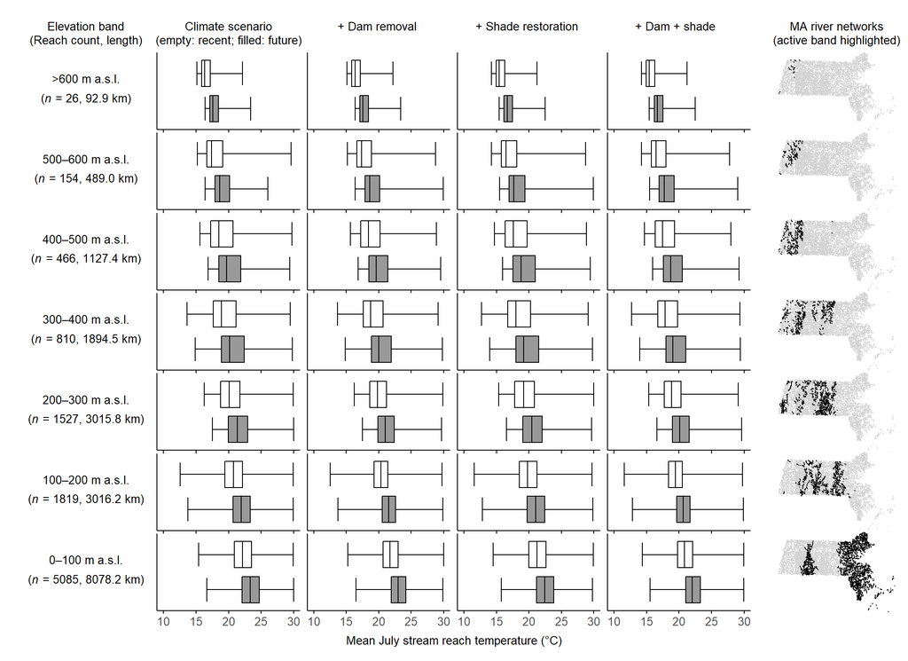

```r
micromap_box_grouped <-
  mmgroupedplot2(
    stat.data   = stats_df_grouped,
    map.data    = map_table,
    panel.types = c("labels","box_summary","box_summary","box_summary","box_summary","map"),
    panel.data  = list(
      "label",
      fn_cols("baseline"),
      fn_cols("dam"),
      fn_cols("shade"),
      fn_cols("damshade"),
      NA
    ),
    grp.by      = "band_id",           #
    cat         = "Climate",
    map.link    = c("band_id", "ID"),  # stat column <-> map_table ID
    map.all     = TRUE,                # show entire network; active band highlighted by color
    colors      = c("white","grey60"),
    plot.footer = "Mean July stream reach temperature (\u00B0C)",
    plot.width = 11,
    plot.height = 8,
    footer.grid.unit.y.adj = 0.025,
    footer.grid.viewport.height = 0.985,
    footer.grid.viewport.y = 0.5,
    panel.att   = list(
      list(1,
           header = "Elevation band\n(Reach count, length)", align = "center",
           panel.width = 1, text.size = 0.9),
      list(2,
           header = 'Climate scenario\n(empty: recent; filled: future)',
           xaxis.title = "",
           graph.bar.size = boxplot_width,
           graph.border.color = NA,
           graph.grid.major = FALSE, graph.grid.minor = FALSE,
           xaxis.ticks = boxplot_axis_ticks,
           xaxis.labels = boxplot_axis_ticks),
      list(3,
           header= "+ Dam removal",
           xaxis.title = "",
           graph.bar.size = boxplot_width,
           graph.border.color = NA,
           graph.grid.major = FALSE, graph.grid.minor = FALSE,
           xaxis.ticks = boxplot_axis_ticks,
           xaxis.labels = boxplot_axis_ticks),
      list(4,
           header = "+ Shade restoration",
           xaxis.title = "",
           graph.bar.size = boxplot_width,
           graph.border.color = NA,
           graph.grid.major = FALSE, graph.grid.minor = FALSE,
           xaxis.ticks = boxplot_axis_ticks,
           xaxis.labels = boxplot_axis_ticks),
      list(5,
           header = "+ Dam + shade ",
           xaxis.title = "",
           graph.bar.size = boxplot_width,
           graph.border.color = NA,
           graph.grid.major = FALSE, graph.grid.minor = FALSE,
           xaxis.ticks = boxplot_axis_ticks,
           xaxis.labels = boxplot_axis_ticks),
      list(6,
           header = "MA river networks\n(active band highlighted)",
           inactive.fill = "lightgray", inactive.border.color = gray(0.7), panel.width = 1)
    )
  )
```

```r
# # PNG figure file
# print.mm2(micromap_box_grouped, res = 1200, footer.grid.unit.y.adj = 0.025,
#                       footer.grid.viewport.height = 0.985,
#                       footer.grid.viewport.y = 0.5,
#           name = "../figures/Figure2_boxplot_temps_micromap.png")
#
# # PDF figure file
# print.mm2(micromap_box_grouped, res = 1200, footer.grid.unit.y.adj = 0.025,
#                       footer.grid.viewport.height = 0.985,
#                       footer.grid.viewport.y = 0.5,
#           name = "../figures/Figure2_boxplot_temps_micromap.pdf")
```

```r
# # eps figure file
# grDevices::cairo_ps(
#   filename = "../figures/Figure2_boxplot_temps_micromap.eps",
#   width = 11,
#   height = 8,
#   onefile = FALSE,
#   family = "sans"
# )
#
# micromap_box_grouped
#
# dev.off()
```

## 3.4 Figure 4. Cold-water habitat barplot micromap

```r
# --- Inputs ---
temp_threshold <- 20
scenarios <- c(
  "Tw_rcnt","Tw_rcntdam","Tw_rcntshade","Tw_rcntdamshade",
  "Tw_futr","Tw_futrdam","Tw_futrshade","Tw_futrdamshade"
)

# Per band/scenario: total km & km at/below 20°C; robust to NAs
prop_long <- streams_banded %>%
  mutate(len_km = seg_len_m / 1000) %>%
  st_drop_geometry() %>%
  select(elev_band, len_km, all_of(scenarios)) %>%
  pivot_longer(cols = all_of(scenarios),
               names_to = "scenario", values_to = "temp_c") %>%
  group_by(elev_band, scenario) %>%
  summarise(
    total_km  = sum(len_km, na.rm = TRUE),
    cool_km   = sum(len_km[temp_c <= temp_threshold], na.rm = TRUE),
    prop_cool = ifelse(total_km > 0, cool_km / total_km, NA_real_),
    .groups   = "drop"
  )

# Also compute per-band totals for label: reach count & total length
band_stats <- streams_banded %>%
  mutate(len_km = seg_len_m / 1000) %>%
  st_drop_geometry() %>%
  group_by(elev_band) %>%
  summarise(
    n_reaches = n(),
    total_km_band = sum(len_km, na.rm = TRUE),
    .groups = "drop"
  )

# Wide table: one row per band with % columns for each scenario
prop_wide <- prop_long %>%
  pivot_wider(
    names_from  = scenario,
    values_from = c(total_km, cool_km, prop_cool),
    names_glue  = "{.value}_{scenario}"
  ) %>%
  arrange(elev_band) %>%
  # Band key + label
  mutate(
    band_id = elev_band
  ) %>%
  left_join(band_stats, by = "elev_band") %>%
  mutate(
    label = sprintf("%s\n(n = %d, %.1f km)", elev_band, n_reaches, total_km_band),
    label_band = sprintf("atop('','%s m a.s.l.')", gsub("-", "\u2013", elev_band)),
    label_band_deets = sprintf("atop('(' * italic(n) * ' = %d, %.1f km)','')",
                               n_reaches, total_km_band)
    )
```

```r
# Percent columns: p20_* = 100 * proportion of km <= 20°C
make_pct_name <- function(s) paste0("p20_", s)
fn_pct <- function(s) make_pct_name(s)

stat_df_prop <- prop_wide %>%
  mutate(across(starts_with("prop_cool_"), ~ .x * 100) )


for (s in scenarios) {
  stat_df_prop[[make_pct_name(s)]] <- stat_df_prop[[paste0("prop_cool_", s)]]
}


ticks_pct <- c(0, 25, 50, 75, 100)
```

```r
stat_df_grouped <- stat_df_prop %>%
  # mutate(Category = elev_band) %>%
  select(
    label, label_band, label_band_deets, band_id,
    p20_Tw_rcnt,         p20_Tw_futr,
    p20_Tw_rcntdam,      p20_Tw_futrdam,
    p20_Tw_rcntshade,    p20_Tw_futrshade,
    p20_Tw_rcntdamshade, p20_Tw_futrdamshade
  ) |>
  pivot_longer(
    cols = starts_with("p20_"),
    names_to = "scenario",
    values_to = "percent"
  ) |>
  mutate(
    Climate = case_when(
      scenario %in% c("p20_Tw_rcnt", "p20_Tw_rcntdam", "p20_Tw_rcntshade", "p20_Tw_rcntdamshade") ~ "Recent",
      scenario %in% c("p20_Tw_futr", "p20_Tw_futrdam", "p20_Tw_futrshade", "p20_Tw_futrdamshade") ~ "Future",
      TRUE ~ NA_character_
    ),
    Restoration = case_when(
      scenario %in% c("p20_Tw_rcnt",        "p20_Tw_futr") ~         "baseline",
      scenario %in% c("p20_Tw_rcntdam",     "p20_Tw_futrdam") ~      "dam",
      scenario %in% c("p20_Tw_rcntshade",   "p20_Tw_futrshade") ~    "shade",
      scenario %in% c("p20_Tw_rcntdamshade","p20_Tw_futrdamshade") ~ "damshade",
      TRUE ~ NA_character_
    )
  ) |>
  select(-scenario) |>
  pivot_wider(
    names_from = "Restoration",
    values_from = "percent"
  ) |>
  mutate(
    Climate = factor(Climate, levels = c("Recent", "Future"))
  ) |>
  mutate(
    Baseline_lo = baseline,
    Baseline_hi = baseline,
    Dam_lo      = dam,
    Dam_hi      = dam,
    Shade_lo    = shade,
    Shade_hi    = shade,
    DamShade_lo = damshade,
    DamShade_hi = damshade,
    label = case_when(
      Climate == "Recent" ~ label_band,
      Climate == "Future" ~ label_band_deets,
      TRUE ~ label
    )
  ) |>
  mutate(band_id = forcats::fct_rev(band_id)) |>
  arrange(band_id, Climate) |>
  data.frame()
```

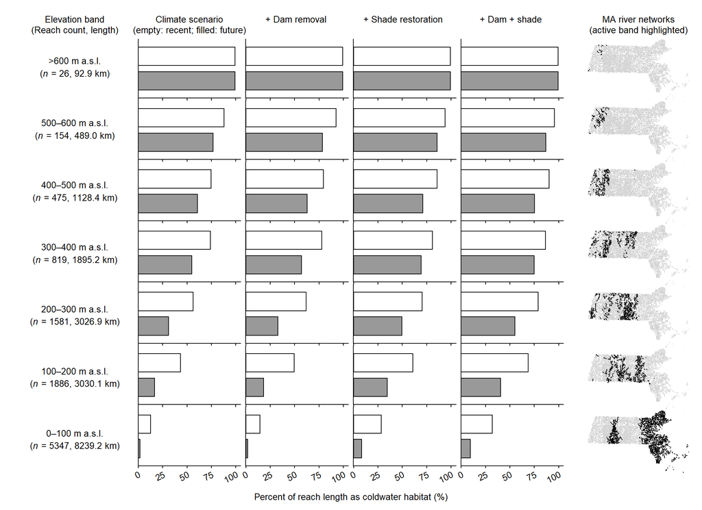

```r
micromap_bar_grouped <- mmgroupedplot2(
  stat.data   = stat_df_grouped,
  map.data    = map_table,
  panel.types = c('labels','bar_cl','bar_cl','bar_cl','bar_cl','map'),
  panel.data  = list('label',
                     list("baseline", "Baseline_lo", "Baseline_hi"),
                     list("dam",      "Dam_lo",      "Dam_hi"),
                     list("shade",    "Shade_lo",    "Shade_hi"),
                     list("damshade", "DamShade_lo", "DamShade_hi"),
                     NA
  ),
  grp.by      = 'band_id',  # geographic unit groups
  cat         = 'Climate',  # categorical variable for different bars w/in a group
  map.link    = c('band_id', 'ID'),
  map.all     = TRUE,
  colors = c("white", "grey60"),
  plot.footer = "Percent of reach length as coldwater habitat (%)",
  plot.grp.spacing = 2,
  plot.height = 8,
  plot.width  = 11,
  footer.grid.unit.y.adj = 0.02,
  footer.grid.viewport.height = 0.97,
  footer.grid.viewport.y = 0.51,
  panel.att   = list(
        list(1,
         header = 'Elevation band\n(Reach count, length)',
         align = 'center',
         panel.width = 1.25,
         text.size = .9),
        list(2,
             header = 'Climate scenario\n(empty: recent; filled: future)',
             graph.border.color = NA,
             graph.bar.size = boxplot_width,
             graph.grid.major = FALSE, graph.grid.minor = FALSE,
             xaxis.ticks  =  ticks_pct,
             xaxis.labels =  ticks_pct
        ),
        list(3,
             header = '+ Dam removal',
             graph.border.color = NA,
             graph.bar.size = boxplot_width,
             graph.grid.major = FALSE, graph.grid.minor = FALSE,
             xaxis.ticks  =  c(0, 25, 50, 75, 100),
             xaxis.labels =  c(0, 25, 50, 75, 100)
        ),
        list(4,
             header = '+ Shade restoration',
             graph.border.color = NA,
             graph.bar.size = boxplot_width,
             graph.grid.major = FALSE, graph.grid.minor = FALSE,
             xaxis.ticks  =  c(0, 25, 50, 75, 100),
             xaxis.labels =  c(0, 25, 50, 75, 100)
        ),
        list(5,
             header = '+ Dam + shade',
             graph.border.color = NA,
             graph.bar.size = boxplot_width,
             graph.grid.major = FALSE, graph.grid.minor = FALSE,
             xaxis.ticks  =  c(0, 25, 50, 75, 100),
             xaxis.labels =  c(0, 25, 50, 75, 100)
        ),
        list(6,
             header = 'MA river networks\n(active band highlighted)',
             inactive.fill = 'lightgray',
             inactive.border.color = gray(.7),
         panel.width = 1.25)
  )
)
```

```r
# print.mm2(micromap_bar_grouped,  res = 1200, footer.grid.unit.y.adj = 0.02,
#                       footer.grid.viewport.height = 0.97,
#                       footer.grid.viewport.y = 0.51,
#           name = "../figures/Figure4_barplot_CWH_micromap.png")
#
# print.mm2(micromap_bar_grouped,  res = 1200, footer.grid.unit.y.adj = 0.0185,
#                       footer.grid.viewport.height = 0.97,
#                       footer.grid.viewport.y = 0.51,
#           name = "../figures/Figure4_barplot_CWH_micromap.pdf")
```

```r
# grDevices::cairo_ps(
#   filename = "../figures/Figure4_barplot_CWH_micromap.eps",
#   width = 11,
#   height = 8,
#   onefile = FALSE,
#   family = "sans"
# )
#
# micromap_bar_grouped
#
# dev.off()
```

# 4 Table 3. Cold-water habitat by elevation - statewide statistics

What is the mean elevation of the cold-water habitat across the state?

```r
# function to generate the state-wide statistics
# requires the augment_df (output from SSN2::augment() function) and a character
# string to name the scenario from with the augment output comes from
cold_water_hab_state_stats_fnx <-
  function(augment_df, scenario_name) {
    augment_df |>
      mutate(Tmean_C = mean(.fitted, na.rm = TRUE),
             Tsd_C = sd(.fitted, na.rm = TRUE)) |>
      filter(.fitted <= 20) |>
      select(v2elevm, Shape_Leng, .fitted, Tmean_C, Tsd_C) |>
      reframe(clim_cond = scenario_name,
              n_sites = n(),
              mean_elevm = round(mean(v2elevm, na.rm = TRUE),2),
              median_elevm = round(median(v2elevm, na.rm = TRUE,),2),
              reach_km = round(sum(Shape_Leng)/1000,2),
              CWHTmean_C = round(mean(.fitted, na.rm = TRUE),2),
              CWHTsd_C = round(sd(.fitted, na.rm = TRUE),2),
              MATmean_C = round(mean(Tmean_C, na.rm = TRUE),2),
              MATsd_C = round(mean(Tsd_C, na.rm = TRUE),2)
      )
  }
```

```r
temp_thshld20c_MA_summary_df <-
  bind_rows(cold_water_hab_state_stats_fnx(augm_rcnt,
                                           "Recent climate (1990-2022)"),
            cold_water_hab_state_stats_fnx(augm_rcntdam,
                                           "Recent climate + dam removal (-1 dam/10km\u00b2)"),
            cold_water_hab_state_stats_fnx(augm_rcntshade,
                                           "Recent climate + riparian shade restoration (+10% shade)"),
            cold_water_hab_state_stats_fnx(augm_rcntdamshade,
                                           "Recent climate + dam removal + shade restoration"),
            cold_water_hab_state_stats_fnx(augm_futr,
                                           "Future climate (+2\u00B0C air temp.)"),
            cold_water_hab_state_stats_fnx(augm_futrdam,
                                           "Future climate + dam removal"),
            cold_water_hab_state_stats_fnx(augm_futrshade,
                                           "Future climate + shade restoration"),
            cold_water_hab_state_stats_fnx(augm_futrdamshade,
                                           "Future climate + dam removal + shade restoration")
  ) |>
  rename("Scenario conditions"="clim_cond",
         "Reach count"="n_sites",
         "Mean elev. (m)"="mean_elevm",
         "Median elev. (m)"="median_elevm",
         "Reach length (km)"="reach_km")

write_csv(temp_thshld20c_MA_summary_df,
          file = "../tables/Table3_coldwaterhabt_count_length_elev_stats.csv")

# use knitr table for PDF output
# knitr::kable(temp_thshld20c_MA_summary_df)

# use DT table for HTML output
DT::datatable(temp_thshld20c_MA_summary_df, rownames = FALSE,
              caption = paste0("State-wide statistics on reach count, length, ",
                               "and elevation for cold water habitat for each scenario."))
```

| Scenario conditions | Reach count | Mean elev. (m) | Median elev. (m) | Reach length (km) | CWHTmean_C | CWHTsd_C | MATmean_C | MATsd_C |
| --- | --- | --- | --- | --- | --- | --- | --- | --- |
| Recent climate (1990-2022) | 2963 | 242.9 | 231.7 | 5034.79 | 18.55 | 1.06 | 21.6 | 3.89 |
| Recent climate + dam removal (-1 dam/10km²) | 3307 | 237.44 | 223.36 | 5528.8 | 18.6 | 1.04 | 21.26 | 3.76 |
| Recent climate + riparian shade restoration (+10% shade) | 4300 | 209.43 | 192.24 | 6939.84 | 18.24 | 1.25 | 20.69 | 3.89 |
| Recent climate + dam removal + shade restoration | 4855 | 204.31 | 187.73 | 7628.38 | 18.28 | 1.23 | 20.35 | 3.76 |
| Future climate (+2°C air temp.) | 1502 | 308.73 | 303.4 | 2791.31 | 18.94 | 0.79 | 22.83 | 3.89 |
| Future climate + dam removal | 1605 | 304.61 | 300.22 | 2930.3 | 18.97 | 0.78 | 22.49 | 3.76 |
| Future climate + shade restoration | 2514 | 259.03 | 250.11 | 4348.44 | 18.65 | 0.99 | 21.92 | 3.89 |
| Future climate + dam removal + shade restoration | 2795 | 253.74 | 243.48 | 4773 | 18.7 | 0.97 | 21.58 | 3.76 |

# 5 Figure 3. Density distributions of cold water habitat

The ridgeline plot compares density distributions of the MA reaches that meet the 20C threshold among scenarios as well as with the density distribution of reaches for all networks in MA. The mean reach length (km) among the MA networks is: 1.321 km with a median of: 0.894. So, there is roughly a 1km reach length across the modeling networks used in this analysis.

```r
#~~~~~~~~~~~~~~~~~~~~~~~~~~~~~~~~~~~~~~~~~~~~~~~~~~~~~~~~~~~~~~~~~~~~~~~~~~~~~~
#  Density ridgeline plots for 20C reaches by elevation gradient(ggplot)
#~~~~~~~~~~~~~~~~~~~~~~~~~~~~~~~~~~~~~~~~~~~~~~~~~~~~~~~~~~~~~~~~~~~~~~~~~~~~~~
augm_binder_df <- mutate(augm_rcnt,     Scenario = "rcnt") %>%
  bind_rows(.,mutate(augm_rcntdam,      Scenario = "rcntdam")) %>%
  bind_rows(.,mutate(augm_rcntshade,    Scenario = "rcntshade")) %>%
  bind_rows(.,mutate(augm_rcntdamshade, Scenario = "rcntdamshade")) %>%
  bind_rows(.,mutate(augm_futr,         Scenario = "futr")) %>%
  bind_rows(.,mutate(augm_futrdam,      Scenario = "futrdam")) %>%
  bind_rows(.,mutate(augm_futrshade,    Scenario = "futrshade")) %>%
  bind_rows(.,mutate(augm_futrdamshade, Scenario = "futrdamshade")) %>%
  select(Scenario, ssnid, pid, COMID, upDist,
         AreaKm2, dJLtavg, BFIc, CPY100x, v2elevm, NIDDENw,
         Tw_pred = .fitted) |>
  mutate(Scenario = factor(Scenario,
                           levels = c("rcnt",
                                      "rcntdam",
                                      "rcntshade",
                                      "rcntdamshade",
                                      "futr",
                                      "futrdam",
                                      "futrshade",
                                      "futrdamshade"
                                      ),
                           labels = c("Recent climate\n(1990\u20132022 average)\n\n\n\n",
                                      "Recent climate +\ndam removal\n(\u22121 dam/10 km\u00b2)\n\n\n\n",
                                      "Recent climate +\nriparian shade restoration\n(+10% shade)\n\n\n\n",
                                      "Recent climate +\ndam removal +\nshade restoration\n\n\n\n",
                                      "Future climate\n(+2\u00B0C air temperature)\n\n\n\n",
                                      "Future climate +\ndam removal\n\n\n\n",
                                      "Future climate +\nshade restoration\n\n\n\n",
                                      "Future climate +\ndam removal +\nshade restoration\n\n\n\n")))
hline_tick_df <- expand_grid(
  x = seq(100, 700, 100),
  y = 2:8
) %>%
  mutate(
    xend = x,
    yend = y,
    y = y - 0.06
  )
```

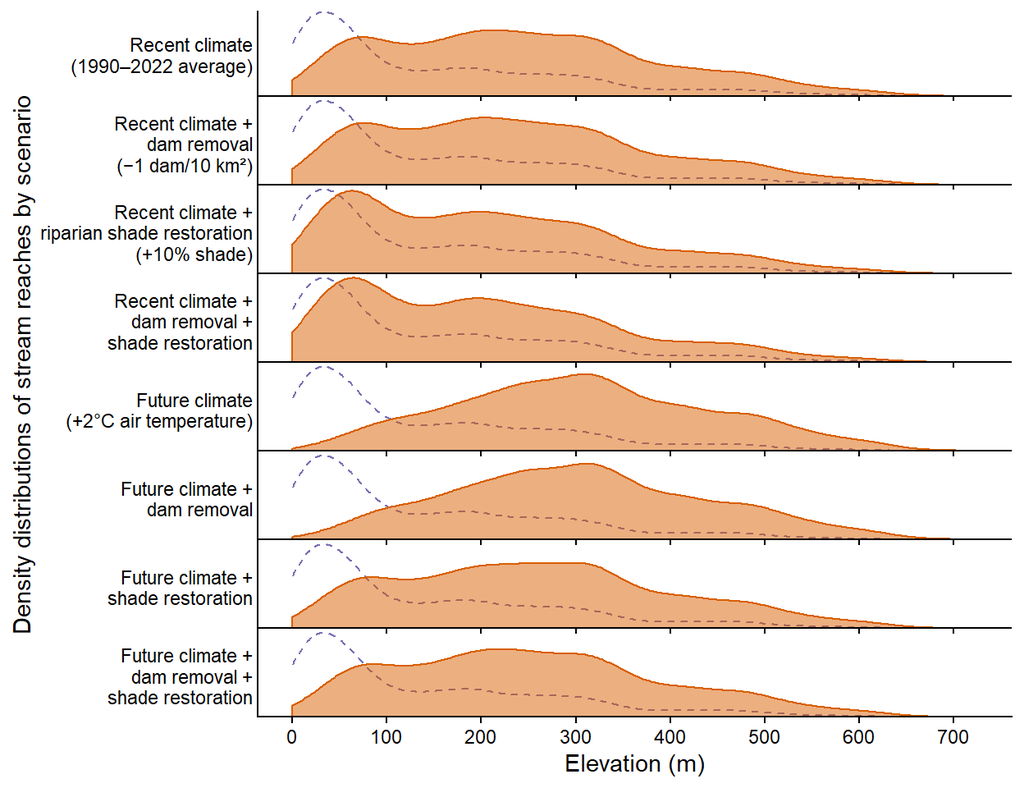

```r
scenario_20C_reaches_by_elevation_ridgesplot <-
  ggplot(data = filter(augm_binder_df, Tw_pred <= 20)) +
  geom_density_ridges(data = augm_binder_df,
                      aes(x = v2elevm, y = Scenario),
                      scale = .95, alpha = 0.5,
                      rel_min_height = 0.005,
                      color = "#7570b3", fill = NA, linetype = "dashed") +
  geom_density_ridges2(aes(x = v2elevm, y = Scenario),
                       scale = .95, alpha = 0.5,
                       rel_min_height = 0.005,
                       color = "#d95f02", fill = "#d95f02") +
  geom_hline(yintercept = 2:8, color = "black", linewidth = 0.5) +
  geom_segment(
    data = hline_tick_df,
    aes(x = x, xend = xend, y = y, yend = yend),
    inherit.aes = FALSE,
    color = "black",
    linewidth = 0.4
  ) +
  theme_classic() +
  theme(plot.caption = element_text(hjust = 1),
        axis.ticks.y = element_blank()) +  # remove y-axis ticks

  scale_y_discrete(limits = rev,  # reverse order of scenarios
                   expand = expansion(mult = c(0, 0.05)) # shrink space btwn xaxis and 1st ridgeline
                   ) +
  scale_x_continuous(breaks = seq(0, 700, 100), limits = c(0,725)) +
  coord_cartesian(xlim = c(0,725)) +
  labs(x = "Elevation (m)",
       y = "Density distributions of stream reaches by scenario")
scenario_20C_reaches_by_elevation_ridgesplot
```

```r
# ggsave(plot = scenario_20C_reaches_by_elevation_ridgesplot,
#        filename = "../figures/Figure3_coldwaterhabitat_ridgelineplot.png",
#        width = 6.5,height = 5, dpi = 600, units = "in")
#
# ggsave(plot = scenario_20C_reaches_by_elevation_ridgesplot,
#        filename = "../figures/Figure3_coldwaterhabitat_ridgelineplot.eps",
#        device = cairo_ps,
#        width = 6.5,height = 5, dpi = 600, units = "in")
```

# 6 Figure 5

## 6.1 Fig 5A. Recent climate cold water habitat availability

```r
# ~~~~~~~~~~~~~~~~~~~~~~~~~~~~~~~~~~~~~~~~~~~~~~~~~~~~~~~~~~~~~~~~~~~~~~~~~~~~~
# BASELINE Recent climate                                        ####
# ~~~~~~~~~~~~~~~~~~~~~~~~~~~~~~~~~~~~~~~~~~~~~~~~~~~~~~~~~~~~~~~~~~~~~~~~~~~~~
# calculate proportions for site number and reach length by elevation band
elev_band_00rcnt <- augm_rcnt |> st_drop_geometry() |>
  group_by(elev_band = cut(v2elevm, breaks= seq(0, 750, elev_band_width_m)) ) |>
  mutate(n_sites_tot = n(),
         reach_km_tot = sum(Shape_Leng)/1000) |> ungroup() |>
  filter(.fitted <= 20) |>
  group_by(elev_band = cut(v2elevm, breaks= seq(0, 750, elev_band_width_m)) ) |>
  reframe(clim_cond = "Recent",
          n_sites = n(),
          reach_km = sum(Shape_Leng)/1000,
          n_sites_tot = max(n_sites_tot),
          reach_km_tot = max(reach_km_tot)) |>
  right_join(elev_threshold_df, by = c("elev_band") ) |>
  mutate(siteprop_n_tot = (n_sites/n_sites_tot),
         siteprop_km_tot = (reach_km/reach_km_tot))

# make plotting data frame for overall cold-water habitat for recent climate
site_prop_rcnt_df <- elev_band_00rcnt |>
  pivot_longer(cols = c("siteprop_n_tot","siteprop_km_tot"),
               names_to = "prop_type", values_to = "proportion") |>
  filter(!is.na(n_sites_tot))
```

```r
siteprop_rcnt_plot_kmonly <-
  ggplot(data = filter(site_prop_rcnt_df, prop_type == "siteprop_km_tot"),
         aes(x = elev_band_mid, y = proportion) ) +
  geom_smooth(color = "grey50", se = FALSE,
              method = 'loess', formula = "y ~ x + 0", span = 0.9,
              linewidth = 1) +
  geom_point(color = "black", shape = 16, size = 2) +
  theme_classic() +
  scale_x_continuous(breaks = seq(0, 700, 100)) +
  coord_cartesian(xlim = c(0,725)) +
  scale_y_continuous(limits = c(0,1)) +
  theme(plot.margin = margin(t = 30, r = 5, b = 5, l = 5)) +
  labs(x = "",
       y = "Proportion of coldwater reach length"
  )
```

## 6.2 Fig 5B. Reach length comparison among all scenarios

```r
#~~~~~~~~~~~~~~~~~~~~~~~~~~~~~~~~~~~~~~~~~~~~~~~~~~~~~~~~~~~~~~~~~~~~~~~~~~~~~~
# SFS building Combo plot for all scenarios' proportion of sites gains/lost ####
#~~~~~~~~~~~~~~~~~~~~~~~~~~~~~~~~~~~~~~~~~~~~~~~~~~~~~~~~~~~~~~~~~~~~~~~~~~~~~~
siteprop_comboclimrest_df <-
  bind_rows(elev_band_proportion_fnx(augm_rcntdam,      "rcntdam"),
            elev_band_proportion_fnx(augm_rcntshade,    "rcntshade"),
            elev_band_proportion_fnx(augm_rcntdamshade, "rcntdamshade"),
            elev_band_proportion_fnx(augm_futr,         "futr"),
            elev_band_proportion_fnx(augm_futrdam,      "futrdam"),
            elev_band_proportion_fnx(augm_futrshade,    "futrshade"),
            elev_band_proportion_fnx(augm_futrdamshade, "futrdamshade")) |>
  mutate(Scenario = factor(clim_cond,
                           levels = c("futr","futrdam","futrshade", "futrdamshade",
                                      "rcntdam","rcntshade","rcntdamshade")))

labels_for_figs <- c(futr =          "Future",
                     futrdam =       "Future + dam",
                     futrshade =     "Future + shade",
                     futrdamshade =  "Future + dam + shade",
                     rcntdam =       "Recent + dam",
                     rcntshade =     "Recent + shade",
                     rcntdamshade =  "Recent + dam + shade")

siteprop_comboclimrest_plot <-
  ggplot() + geom_hline(yintercept = 0, color = "grey50", linewidth = 0.75) +

  geom_smooth(data = filter(siteprop_comboclimrest_df,
                            Scenario %in% c("rcntdam","rcntshade","rcntdamshade",
                                            "futr",
                                            "futrdam","futrshade","futrdamshade")),
              se = FALSE, level = 0.95, method = "loess", formula = 'y~x',
              aes(x = elev_band_mid,
                  color = Scenario,
                  fill = Scenario,
                  linetype = Scenario,
                  linewidth = Scenario,
                  y = siteprop_n) ) +

  theme_classic() +
  scale_linetype_manual(name = "Scenario",
                        values = c("dashed","dotdash","dotdash","solid",
                                   "dotted","dotted","dotted"),
                        labels = labels_for_figs) +
  scale_linewidth_manual(name = "Scenario",
                         values = c(1,1,1,1.5,1,1,1),
                         labels = labels_for_figs) +
  scale_color_manual(name = "Scenario",
                     values = c('#b35806','#f1a340','#fee0b6','black',
                                '#d8daeb','#998ec3','#542788'),
                     labels = labels_for_figs) +
  scale_fill_manual(name = "Scenario",
                    values = c('#b35806','#f1a340','#fee0b6','black',
                               '#d8daeb','#998ec3','#542788'),
                    labels = labels_for_figs) +
  scale_y_continuous(breaks = seq(-1, 2, 1),
                     labels = ~sub("-", "\u2212", .x)) +
  scale_x_continuous(breaks = seq(0, 700, 100)) +
  coord_cartesian(ylim = c(-1, 2), xlim = c(0,725)) +
  theme(legend.position = c(0.6,0.8),
        plot.title = element_markdown(),    # used for double line subtitle
        plot.subtitle = element_markdown(), # used for double line subtitle
        legend.background = element_blank(),
        legend.key = element_blank(),
        legend.key.width = unit(0.5,"in"),  # increase width of legend keys
        legend.direction = "horizontal",
        legend.text.align = 0) +
  guides(color = guide_legend(nrow = 4),
         fill = guide_legend(nrow = 4),
         linetype = guide_legend(nrow = 4),
         linewidth = guide_legend(nrow = 4)) +
  labs(x = "Reach elevation (m)",
       y = "Proportion of coldwater habitat\n(reach length gained [+] or lost [-])"
  )
```

## 6.3 Figure 5. Panel Plot

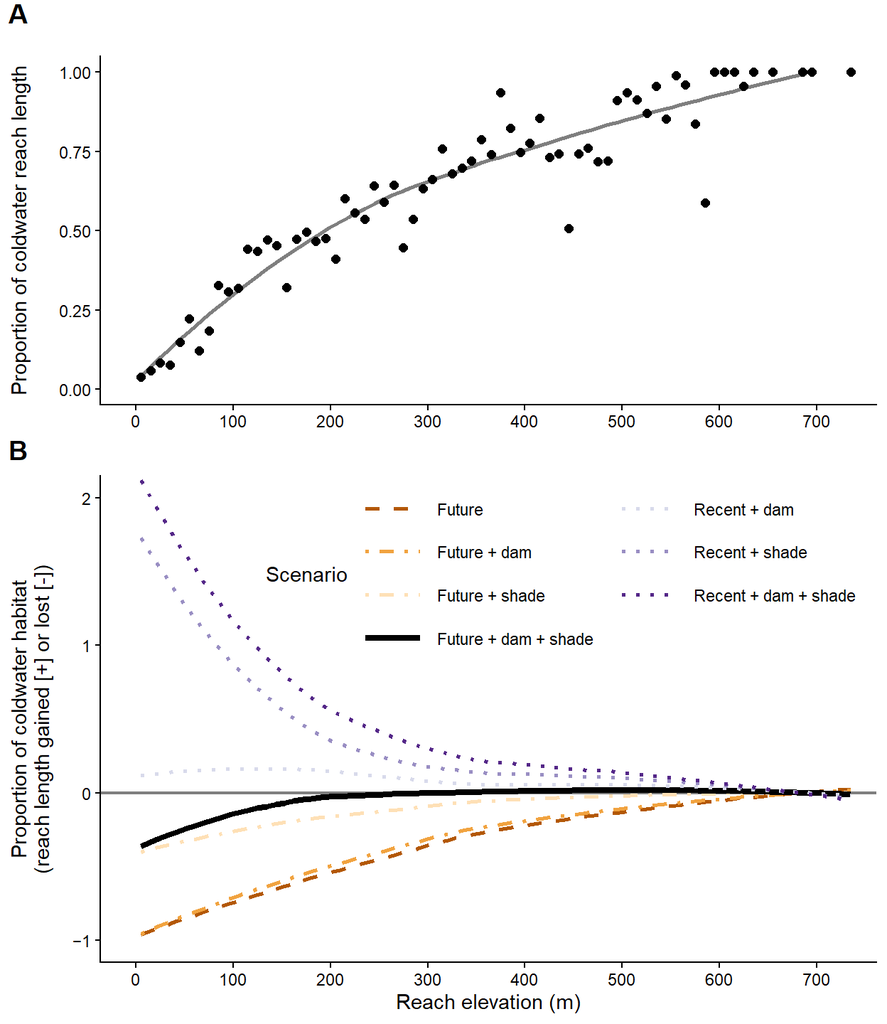

```r
figure_5_panel_plot <-
  cowplot::plot_grid(siteprop_rcnt_plot_kmonly, siteprop_comboclimrest_plot,
                   labels = c("A","B"),
                   label_x = 0.01,
                   label_y = c(0.95, 1.01),
                   rel_heights = c(1,1.2),
                   align = "v",
                   hjust = 0,
                   vjust = 0,
                   nrow = 2) +
  theme(plot.background = element_rect(fill = "white",color = NA))
figure_5_panel_plot
```

```r
# ggsave(plot = figure_5_panel_plot,
#        filename = paste0("../figures/",
#                          "Figure5_coldwaterhabitat_proportions.png"),
#        width = 6.5, height = 7.5, units = "in", dpi = 600)
#
# ggsave(plot = figure_5_panel_plot,
#        filename = paste0("../figures/",
#                          "Figure5_coldwaterhabitat_proportions.eps"),
#        device = cairo_ps,
#        width = 6.5, height = 7.5, units = "in", dpi = 600)
```

# 7 Supporting Information

## 7.1 Figure S1. CWH by elevation threshhold comparison

```r
# ~~~~~~~~~~~~~~~~~~~~~~~~~~~~~~~~~~~~~~~~~~~~~~~~~~~~~~~~~~~~~~~~~~~~~~~~~~~~~
# BASELINE Recent climate                                        ####
# ~~~~~~~~~~~~~~~~~~~~~~~~~~~~~~~~~~~~~~~~~~~~~~~~~~~~~~~~~~~~~~~~~~~~~~~~~~~~~
# calculate proportions for site number and reach length by elevation band
elev_band_00rcnt18 <- augm_rcnt |> st_drop_geometry() |>
  group_by(elev_band = cut(v2elevm, breaks= seq(0, 750, elev_band_width_m)) ) |>
  mutate(n_sites_tot = n(),
         reach_km_tot = sum(Shape_Leng)/1000) |> ungroup() |>
  filter(.fitted <= 18) |>
  group_by(elev_band = cut(v2elevm, breaks= seq(0, 750, elev_band_width_m)) ) |>
  reframe(clim_cond = "Recent",
          n_sites = n(),
          reach_km = sum(Shape_Leng)/1000,
          n_sites_tot = max(n_sites_tot),
          reach_km_tot = max(reach_km_tot)) |>
  right_join(elev_threshold_df, by = c("elev_band") ) |>
  mutate(siteprop_n_tot = (n_sites/n_sites_tot),
         siteprop_km_tot = (reach_km/reach_km_tot))

# make plotting data frame for overall cold-water habitat for recent climate
site_prop_rcnt18_df <- elev_band_00rcnt18 |>
  pivot_longer(cols = c("siteprop_n_tot","siteprop_km_tot"),
               names_to = "prop_type", values_to = "proportion") |>
  filter(!is.na(n_sites_tot))



# calculate proportions for site number and reach length by elevation band
elev_band_00rcnt19 <- augm_rcnt |> st_drop_geometry() |>
  group_by(elev_band = cut(v2elevm, breaks= seq(0, 750, elev_band_width_m)) ) |>
  mutate(n_sites_tot = n(),
         reach_km_tot = sum(Shape_Leng)/1000) |> ungroup() |>
  filter(.fitted <= 19) |>
  group_by(elev_band = cut(v2elevm, breaks= seq(0, 750, elev_band_width_m)) ) |>
  reframe(clim_cond = "Recent",
          n_sites = n(),
          reach_km = sum(Shape_Leng)/1000,
          n_sites_tot = max(n_sites_tot),
          reach_km_tot = max(reach_km_tot)) |>
  right_join(elev_threshold_df, by = c("elev_band") ) |>
  mutate(siteprop_n_tot = (n_sites/n_sites_tot),
         siteprop_km_tot = (reach_km/reach_km_tot))

# make plotting data frame for overall cold-water habitat for recent climate
site_prop_rcnt19_df <- elev_band_00rcnt19 |>
  pivot_longer(cols = c("siteprop_n_tot","siteprop_km_tot"),
               names_to = "prop_type", values_to = "proportion") |>
  filter(!is.na(n_sites_tot))



# calculate proportions for site number and reach length by elevation band
elev_band_00rcnt20 <- augm_rcnt |> st_drop_geometry() |>
  group_by(elev_band = cut(v2elevm, breaks= seq(0, 750, elev_band_width_m)) ) |>
  mutate(n_sites_tot = n(),
         reach_km_tot = sum(Shape_Leng)/1000) |> ungroup() |>
  filter(.fitted <= 20) |>
  group_by(elev_band = cut(v2elevm, breaks= seq(0, 750, elev_band_width_m)) ) |>
  reframe(clim_cond = "Recent",
          n_sites = n(),
          reach_km = sum(Shape_Leng)/1000,
          n_sites_tot = max(n_sites_tot),
          reach_km_tot = max(reach_km_tot)) |>
  right_join(elev_threshold_df, by = c("elev_band") ) |>
  mutate(siteprop_n_tot = (n_sites/n_sites_tot),
         siteprop_km_tot = (reach_km/reach_km_tot))

# make plotting data frame for overall cold-water habitat for recent climate
site_prop_rcnt20_df <- elev_band_00rcnt20 |>
  pivot_longer(cols = c("siteprop_n_tot","siteprop_km_tot"),
               names_to = "prop_type", values_to = "proportion") |>
  filter(!is.na(n_sites_tot))

site_prop_rcnt181920_df <- bind_rows(
  mutate(site_prop_rcnt18_df, t_thresh = factor("18", levels = c("18","19","20"))),
  mutate(site_prop_rcnt19_df, t_thresh = factor("19", levels = c("18","19","20"))),
  mutate(site_prop_rcnt20_df, t_thresh = factor("20", levels = c("18","19","20")))
)
```

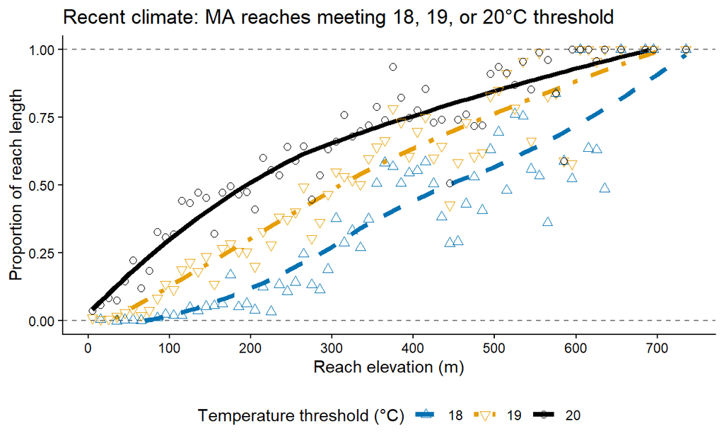

```r
(siteprop_rcnt_plot_temp_threshold <-
   ggplot(data = filter(site_prop_rcnt181920_df, prop_type == "siteprop_km_tot"),
          aes(x = elev_band_mid, y = proportion,
              color = t_thresh, shape = t_thresh, linetype = t_thresh) ) +
   geom_hline(yintercept = 0, linetype = "dashed", color = "grey50") +
   geom_hline(yintercept = 1, linetype = "dashed", color = "grey50") +

   geom_smooth(se = FALSE, linewidth = 1.5,
               method = 'loess', formula = "y ~ x + 0", span = 0.9,
               fullrange = FALSE) +

   geom_point(size = 2) +

   theme_classic() +
   scale_y_continuous(limits = c(0,1)) +
   scale_color_manual(breaks = c("18","19","20"),
                      values = c("#0072B2","#E69F00","black") ) +
   scale_linetype_manual(breaks = c("18","19","20"),
                      values = c("dashed","dotdash","solid") ) +
   scale_shape_manual(breaks = c("18","19","20"),
                      values = c(2,6,1) ) +
   scale_x_continuous(breaks = seq(0, 700, 100)) +
   theme(legend.position = "bottom") +
   labs(x = "Reach elevation (m)",
        title = "Recent climate: MA reaches meeting 18, 19, or 20\u00B0C threshold",
        color = "Temperature threshold (\u00B0C)",
        linetype = "Temperature threshold (\u00B0C)",
        shape = "Temperature threshold (\u00B0C)",
        y = "Proportion of reach length") )
```

```r
# ggsave(plot = siteprop_rcnt_plot_temp_threshold, width = 6.5, height = 4, units = "in", dpi = 600,
#        filename = "../figures/FigureS1_coldwaterhabitat_available_in_recent_climate_thresholdcomparison.png")
#
# ggsave(plot = siteprop_rcnt_plot_temp_threshold, width = 6.5, height = 4, units = "in", dpi = 600,
#        device = cairo_ps,
#        filename = "../figures/FigureS1_coldwaterhabitat_available_in_recent_climate_thresholdcomparison.eps")
```